# Loan Default Prediction using Classification Algorithms

## Goal: compare 5 major ML models for Classification based on how well they can predict whether a given loan will default

### We used PyCaret library to build train and test models on Peer-to-Peer (P2P) loan data from Lending Club

### To evaluate whether a given loan will default, we build classification models based on various features (characteristics of loan and borrower) from a public corpus of loans from 2007-2018 (2.2M loans granted),

### The loans can broadly be in one of 4 statuses: fully paid, charged-off, default, or active (includes 30d, 120d past due).

### We use the loans for which the final outcome is known (paid-off, default, paid in full or charged-off) to test and train various ML models

```python
# Import all libraries needed
import os
import pandas as pd
import numpy as np
import matplotlib.pyplot as plt
import seaborn as sns
import warnings
import itertools
import pickle
import pycaret


from IPython.display import display
from IPython.core.display import HTML

from sklearn.model_selection import train_test_split
from sklearn.ensemble import RandomForestClassifier
from sklearn.neighbors import KNeighborsClassifier
from sklearn.metrics import accuracy_score
from sklearn import preprocessing,metrics
from sklearn import linear_model,svm
from sklearn.metrics import average_precision_score
from sklearn.metrics import precision_recall_curve

from pycaret.classification import *

# from pandas_profiling import ProfileReport



# Setting options
pd.set_option("display.max_columns", 150)
pd.set_option('display.float_format', lambda x: '%.4f' % x)
pd.set_option("display.precision", 4)
warnings.filterwarnings('ignore')

# Make charts inline
%matplotlib inline
```

```python
# pip install shap
# !pip install pycaret --no-dependencies
```

## Import Original Dataset and check for size (~2.26M rows and 145 columns) for loans issued between 2007-2018 data

## However since loans can be 3 or 5 year, some of the repaymnet status will be incomplete and sometimes unknown.

## So we will only use data between Jan 2013-Jan 2015 because these loans will have definitive data on whether they are defaulted/charged off/paid in full

```python
df = pd.read_csv("loan.csv")
print("Original Data Shape: ", df.shape)
```

```
Original Data Shape:  (2260668, 145)
```

### Remove empty columns (all values are missing) or columns which don't have over 90% non-empty rows values

#### Empty columns are mostly the ones containing NPI information that was not released in the public dataset

#### Original loans dataset has 145 columns and after filtering out the empty columns and columns where threhold was not met there are 86 columns left

#### The resulting filtered dataset has ~370K rows (loans) and 85 columns that are potential features or predictor variables and loan_status output or response variable

```python
loan_dataset_nonempty = df.dropna(axis='columns', how='all')
print("Original Data Shape After dropping empty columns: ", loan_dataset_nonempty.shape)
row,col = loan_dataset_nonempty.shape
loan_dataset_thresh = loan_dataset_nonempty.dropna(axis='columns', thresh=0.9*row)
print("Original Data Shape After dropping columns with more than 10% empty values: ", loan_dataset_thresh.shape)
# print(loan_dataset_thresh)
loan_dataset_thresh.head()
dataset = loan_dataset_thresh
# dataset.describe(include='all')
print('Numeric Columns: ')
display(dataset.describe(include=[np.number]))
print('String Columns: ')
display(dataset.describe(include=[np.object]))


# print('Categorical Columns: ')
# dataset.describe(include=['category'])


# Filter the data for yeasr 2012 -2015
# dataset.info(null_counts=True, verbose=True)
dataset['issue_d'] = pd.to_datetime(dataset.issue_d, format='%b-%Y')
# display(dataset['issue_d'])
start_date = '2013-01-01'
end_date = '2015-01-01'
mask = (dataset['issue_d'] >= start_date) & (dataset['issue_d'] < end_date)
dataset = dataset.loc[mask]
display("Current dataset size for 2013-2014 data: ", dataset.shape)
display(dataset.head(5))
```

```
Original Data Shape After dropping empty columns:  (2260668, 142)
Original Data Shape After dropping columns with more than 10% empty values:  (2260668, 86)
Numeric Columns:
```

|  | loan_amnt | funded_amnt | funded_amnt_inv | int_rate | installment | annual_inc | dti | delinq_2yrs | inq_last_6mths | open_acc | pub_rec | revol_bal | revol_util | total_acc | out_prncp | out_prncp_inv | total_pymnt | total_pymnt_inv | total_rec_prncp | total_rec_int | total_rec_late_fee | recoveries | collection_recovery_fee | last_pymnt_amnt | collections_12_mths_ex_med | policy_code | acc_now_delinq | tot_coll_amt | tot_cur_bal | … |
| --- | --- | --- | --- | --- | --- | --- | --- | --- | --- | --- | --- | --- | --- | --- | --- | --- | --- | --- | --- | --- | --- | --- | --- | --- | --- | --- | --- | --- | --- | --- |
| count | 2260668.0000 | 2260668.0000 | 2260668.0000 | 2260668.0000 | 2260668.0000 | 2260664.0000 | 2258957.0000 | 2260639.0000 | 2260638.0000 | 2260639.0000 | 2260639.0000 | 2260668.0000 | 2258866.0000 | 2260639.0000 | 2260668.0000 | 2260668.0000 | 2260668.0000 | 2260668.0000 | 2260668.0000 | 2260668.0000 | 2260668.0000 | 2260668.0000 | 2260668.0000 | 2260668.0000 | 2260523.0000 | 2260668.0000 | 2260639.0000 | 2190392.0000 | 2190392.0000 | … |
| mean | 15046.9312 | 15041.6641 | 15023.4376 | 13.0929 | 445.8076 | 77992.4287 | 18.8242 | 0.3069 | 0.5768 | 11.6124 | 0.1975 | 16658.4581 | 50.3377 | 24.1626 | 4446.2929 | 4445.2949 | 11824.0305 | 11805.9435 | 9300.1421 | 2386.3520 | 1.4625 | 136.0740 | 22.5933 | 3364.0153 | 0.0181 | 1.0000 | 0.0041 | 232.7317 | 142492.1952 | … |
| std | 9190.2455 | 9188.4130 | 9192.3318 | 4.8321 | 267.1737 | 112696.1996 | 14.1833 | 0.8672 | 0.8860 | 5.6409 | 0.5705 | 22948.3050 | 24.7131 | 11.9875 | 7547.6117 | 7546.6569 | 9889.5990 | 9884.8347 | 8304.8856 | 2663.0861 | 11.5021 | 725.8317 | 127.1114 | 5971.7574 | 0.1508 | 0.0000 | 0.0696 | 8518.4618 | 160692.6406 | … |
| min | 500.0000 | 500.0000 | 0.0000 | 5.3100 | 4.9300 | 0.0000 | -1.0000 | 0.0000 | 0.0000 | 0.0000 | 0.0000 | 0.0000 | 0.0000 | 1.0000 | 0.0000 | 0.0000 | 0.0000 | 0.0000 | 0.0000 | 0.0000 | -0.0000 | 0.0000 | 0.0000 | 0.0000 | 0.0000 | 1.0000 | 0.0000 | 0.0000 | 0.0000 | … |
| 25% | 8000.0000 | 8000.0000 | 8000.0000 | 9.4900 | 251.6500 | 46000.0000 | 11.8900 | 0.0000 | 0.0000 | 8.0000 | 0.0000 | 5950.0000 | 31.5000 | 15.0000 | 0.0000 | 0.0000 | 4272.5800 | 4257.7300 | 2846.1800 | 693.6100 | 0.0000 | 0.0000 | 0.0000 | 308.6400 | 0.0000 | 1.0000 | 0.0000 | 0.0000 | 29092.0000 | … |
| 50% | 12900.0000 | 12875.0000 | 12800.0000 | 12.6200 | 377.9900 | 65000.0000 | 17.8400 | 0.0000 | 0.0000 | 11.0000 | 0.0000 | 11324.0000 | 50.3000 | 22.0000 | 0.0000 | 0.0000 | 9060.8699 | 9043.0800 | 6823.3850 | 1485.2800 | 0.0000 | 0.0000 | 0.0000 | 588.4700 | 0.0000 | 1.0000 | 0.0000 | 0.0000 | 79240.0000 | … |
| 75% | 20000.0000 | 20000.0000 | 20000.0000 | 15.9900 | 593.3200 | 93000.0000 | 24.4900 | 0.0000 | 1.0000 | 14.0000 | 0.0000 | 20246.0000 | 69.4000 | 31.0000 | 6712.6325 | 6710.3200 | 16707.9727 | 16682.5725 | 13397.5000 | 3052.2200 | 0.0000 | 0.0000 | 0.0000 | 3534.9650 | 0.0000 | 1.0000 | 0.0000 | 0.0000 | 213204.0000 | … |
| max | 40000.0000 | 40000.0000 | 40000.0000 | 30.9900 | 1719.8300 | 110000000.0000 | 999.0000 | 58.0000 | 33.0000 | 101.0000 | 86.0000 | 2904836.0000 | 892.3000 | 176.0000 | 40000.0000 | 40000.0000 | 63296.8779 | 63296.8800 | 40000.0000 | 28192.5000 | 1427.2500 | 39859.5500 | 7174.7190 | 42192.0500 | 20.0000 | 1.0000 | 14.0000 | 9152545.0000 | 9971659.0000 | … |

```
String Columns:
```

|  | term | grade | sub_grade | emp_title | emp_length | home_ownership | verification_status | issue_d | loan_status | pymnt_plan | purpose | title | zip_code | addr_state | earliest_cr_line | initial_list_status | last_pymnt_d | last_credit_pull_d | application_type | hardship_flag | disbursement_method | debt_settlement_flag |
| --- | --- | --- | --- | --- | --- | --- | --- | --- | --- | --- | --- | --- | --- | --- | --- | --- | --- | --- | --- | --- | --- | --- |
| count | 2260668 | 2260668 | 2260668 | 2093699 | 2113761 | 2260668 | 2260668 | 2260668 | 2260668 | 2260668 | 2260668 | 2237343 | 2260667 | 2260668 | 2260639 | 2260668 | 2258242 | 2260595 | 2260668 | 2260668 | 2260668 | 2260668 |
| unique | 2 | 7 | 35 | 512694 | 11 | 6 | 3 | 139 | 9 | 2 | 14 | 63155 | 956 | 51 | 754 | 2 | 135 | 140 | 2 | 2 | 2 | 2 |
| top | 36 months | B | C1 | Teacher | 10+ years | MORTGAGE | Source Verified | Mar-2016 | Fully Paid | n | debt_consolidation | Debt consolidation | 112xx | CA | Sep-2004 | w | Feb-2019 | Feb-2019 | Individual | N | Cash | N |
| freq | 1609754 | 663557 | 145903 | 38824 | 748005 | 1111450 | 886231 | 61992 | 1041952 | 2259986 | 1277877 | 1153293 | 23908 | 314533 | 15400 | 1535467 | 934725 | 1398266 | 2139958 | 2259783 | 2182546 | 2227612 |

```
'Current dataset size for 2013-2014 data: '
```

```
(370443, 86)
```

|  | loan_amnt | funded_amnt | funded_amnt_inv | term | int_rate | installment | grade | sub_grade | emp_title | emp_length | home_ownership | annual_inc | verification_status | issue_d | loan_status | pymnt_plan | purpose | title | zip_code | addr_state | dti | delinq_2yrs | earliest_cr_line | inq_last_6mths | open_acc | pub_rec | revol_bal | revol_util | total_acc | … |
| --- | --- | --- | --- | --- | --- | --- | --- | --- | --- | --- | --- | --- | --- | --- | --- | --- | --- | --- | --- | --- | --- | --- | --- | --- | --- | --- | --- | --- | --- | --- |
| 1675675 | 12000 | 12000 | 12000.0000 | 36 months | 6.6200 | 368.4500 | A | A2 | MANAGER INFORMATION DELIVERY | 10+ years | MORTGAGE | 105000.0000 | Not Verified | 2013-12-01 | Fully Paid | n | debt_consolidation | UNIVERSAL CARD | 060xx | CT | 14.0500 | 0.0000 | Mar-1994 | 1.0000 | 12.0000 | 0.0000 | 13168 | 21.6000 | 22.0000 | … |
| 1675676 | 28000 | 28000 | 28000.0000 | 36 months | 7.6200 | 872.5200 | A | A3 | Area Sales Manager | 5 years | MORTGAGE | 325000.0000 | Source Verified | 2013-12-01 | Fully Paid | n | debt_consolidation | Pay off other Installment loan | 945xx | CA | 18.5500 | 0.0000 | Nov-1994 | 1.0000 | 15.0000 | 0.0000 | 29581 | 54.6000 | 31.0000 | … |
| 1675677 | 27050 | 27050 | 27050.0000 | 36 months | 10.9900 | 885.4600 | B | B2 | Team Leadern Customer Ops & Systems | 10+ years | OWN | 55000.0000 | Verified | 2013-12-01 | Fully Paid | n | debt_consolidation | Debt Consolidation | 481xx | MI | 22.8700 | 0.0000 | Oct-1986 | 0.0000 | 14.0000 | 0.0000 | 36638 | 61.2000 | 27.0000 | … |
| 1675678 | 12000 | 12000 | 12000.0000 | 36 months | 11.9900 | 398.5200 | B | B3 | LTC | 10+ years | MORTGAGE | 130000.0000 | Source Verified | 2013-12-01 | Fully Paid | n | debt_consolidation | Debt consolidation | 809xx | CO | 13.0300 | 0.0000 | Nov-1997 | 1.0000 | 9.0000 | 0.0000 | 10805 | 67.0000 | 19.0000 | … |
| 1675679 | 12000 | 12000 | 12000.0000 | 36 months | 7.6200 | 373.9400 | A | A3 | Systems Engineer | 3 years | MORTGAGE | 96500.0000 | Not Verified | 2013-12-01 | Fully Paid | n | debt_consolidation | Debt Consolidation and Credit Transfer | 782xx | TX | 12.6100 | 0.0000 | Sep-2003 | 0.0000 | 17.0000 | 0.0000 | 13248 | 55.7000 | 30.0000 | … |

```python
# # Explore cardinality and histograms for categorical variables
# t = {e:dataset[e].unique() for e in dataset.select_dtypes(include=np.object).columns}
# display(t)
# s = {e:dataset[e].value_counts() for e in dataset.select_dtypes(include=np.object).columns}
# display(s)
```

## Basic exploration of shape of each variable in dataset

### categorical variables: understand cardinality and frequency distributions

### numerical variables: understand distributions by using univariate stats (mean, median, mode, quartiles, min/max)

```python
dataset.describe(include='all')
```

|  | loan_amnt | funded_amnt | funded_amnt_inv | term | int_rate | installment | grade | sub_grade | emp_title | emp_length | home_ownership | annual_inc | verification_status | issue_d | loan_status | pymnt_plan | purpose | title | zip_code | addr_state | dti | delinq_2yrs | earliest_cr_line | inq_last_6mths | open_acc | pub_rec | revol_bal | revol_util | total_acc | … |
| --- | --- | --- | --- | --- | --- | --- | --- | --- | --- | --- | --- | --- | --- | --- | --- | --- | --- | --- | --- | --- | --- | --- | --- | --- | --- | --- | --- | --- | --- | --- |
| count | 370443.0000 | 370443.0000 | 370443.0000 | 370443 | 370443.0000 | 370443.0000 | 370443 | 370443 | 348642 | 352462 | 370443 | 370443.0000 | 370443 | 370443 | 370443 | 370443 | 370443 | 370438 | 370443 | 370443 | 370443.0000 | 370443.0000 | 370443 | 370443.0000 | 370443.0000 | 370443.0000 | 370443.0000 | 370240.0000 | 370443.0000 | … |
| unique | nan | nan | nan | 2 | nan | nan | 7 | 35 | 150719 | 11 | 4 | nan | 3 | 24 | 6 | 2 | 13 | 33365 | 873 | 50 | nan | nan | 656 | nan | nan | nan | nan | nan | nan | … |
| top | nan | nan | nan | 36 months | nan | nan | B | B4 | Teacher | 10+ years | MORTGAGE | nan | Verified | 2014-10-01 00:00:00 | Fully Paid | n | debt_consolidation | Debt consolidation | 945xx | CA | nan | nan | Aug-2000 | nan | nan | nan | nan | nan | nan | … |
| freq | nan | nan | nan | 262992 | nan | nan | 106051 | 24046 | 5401 | 125308 | 192002 | nan | 133372 | 38783 | 294183 | 370435 | 223646 | 159207 | 4061 | 54754 | nan | nan | 2915 | nan | nan | nan | nan | nan | nan | … |
| first | nan | nan | nan | NaN | nan | nan | NaN | NaN | NaN | NaN | NaN | nan | NaN | 2013-01-01 00:00:00 | NaN | NaN | NaN | NaN | NaN | NaN | nan | nan | NaN | nan | nan | nan | nan | nan | nan | … |
| last | nan | nan | nan | NaN | nan | nan | NaN | NaN | NaN | NaN | NaN | nan | NaN | 2014-12-01 00:00:00 | NaN | NaN | NaN | NaN | NaN | NaN | nan | nan | NaN | nan | nan | nan | nan | nan | nan | … |
| mean | 14810.9303 | 14810.9148 | 14805.0889 | NaN | 14.0469 | 446.0703 | NaN | NaN | NaN | NaN | NaN | 74262.3816 | NaN | NaN | NaN | NaN | NaN | NaN | NaN | NaN | 17.7414 | 0.3118 | NaN | 0.7694 | 11.4798 | 0.1913 | 16614.4718 | 56.7391 | 25.6115 | … |
| std | 8316.6723 | 8316.6725 | 8313.6535 | NaN | 4.3824 | 243.5415 | NaN | NaN | NaN | NaN | NaN | 53204.2453 | NaN | NaN | NaN | NaN | NaN | NaN | NaN | NaN | 7.8801 | 0.8415 | NaN | 1.0367 | 5.0590 | 0.5589 | 21219.1608 | 22.9276 | 11.6254 | … |
| min | 1000.0000 | 1000.0000 | 950.0000 | NaN | 6.0000 | 4.9300 | NaN | NaN | NaN | NaN | NaN | 3000.0000 | NaN | NaN | NaN | NaN | NaN | NaN | NaN | NaN | 0.0000 | 0.0000 | NaN | 0.0000 | 0.0000 | 0.0000 | 0.0000 | 0.0000 | 2.0000 | … |
| 25% | 8400.0000 | 8400.0000 | 8400.0000 | NaN | 10.9900 | 269.9800 | NaN | NaN | NaN | NaN | NaN | 45500.0000 | NaN | NaN | NaN | NaN | NaN | NaN | NaN | NaN | 11.8200 | 0.0000 | NaN | 0.0000 | 8.0000 | 0.0000 | 6684.0000 | 40.3000 | 17.0000 | … |
| 50% | 13000.0000 | 13000.0000 | 13000.0000 | NaN | 13.9800 | 392.6600 | NaN | NaN | NaN | NaN | NaN | 64647.0000 | NaN | NaN | NaN | NaN | NaN | NaN | NaN | NaN | 17.3400 | 0.0000 | NaN | 0.0000 | 11.0000 | 0.0000 | 12061.0000 | 57.8000 | 24.0000 | … |
| 75% | 20000.0000 | 20000.0000 | 20000.0000 | NaN | 16.9900 | 582.3500 | NaN | NaN | NaN | NaN | NaN | 90000.0000 | NaN | NaN | NaN | NaN | NaN | NaN | NaN | NaN | 23.4000 | 0.0000 | NaN | 1.0000 | 14.0000 | 0.0000 | 20762.0000 | 74.5000 | 32.0000 | … |
| max | 35000.0000 | 35000.0000 | 35000.0000 | NaN | 26.0600 | 1409.9900 | NaN | NaN | NaN | NaN | NaN | 7500000.0000 | NaN | NaN | NaN | NaN | NaN | NaN | NaN | NaN | 39.9900 | 29.0000 | NaN | 6.0000 | 84.0000 | 63.0000 | 2568995.0000 | 892.3000 | 156.0000 | … |

### Map correlations between variables in dataset to remove highly correlated predictor variables from model

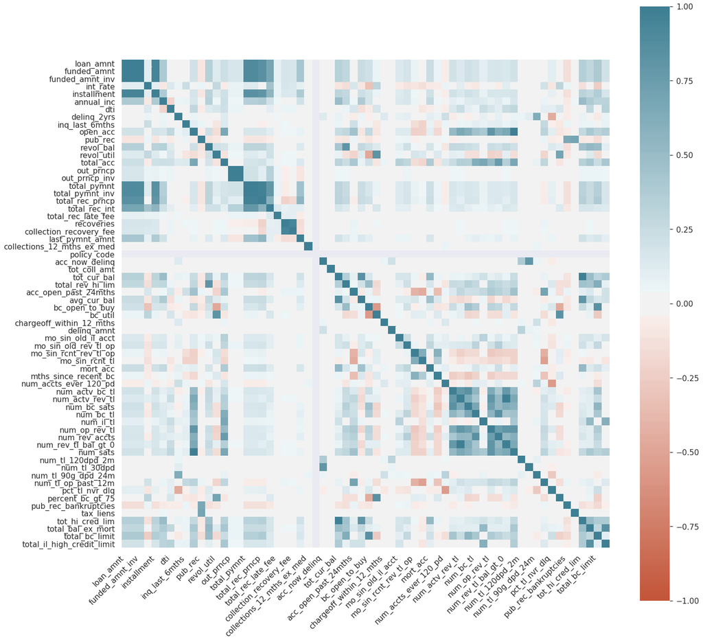

```python
num_vars = dataset.select_dtypes(include=[np.number])
num_features = len(num_vars.columns)
features = len(num_vars)
# display(num_features)
# g = sns.PairGrid(num_vars)
# g.map_diag(sns.distplot)
# g.map_offdiag(sns.kdeplot, n_levels=10);

# sns.pairplot(dataset, hue="loan_status", height=2.5);

corr = num_vars.corr()

corr_matrix = corr.abs()

#the matrix is symmetric so we need to extract upper triangle matrix without diagonal (k = 1)

# sol = (corr_matrix.where(np.triu(np.ones(corr_matrix.shape), k=1).astype(np.bool))
#                  .stack()
#                  .sort_values(ascending=False))
# display(sol)

corr_red = corr # [(corr >= 0.7) | (corr <= -0.7)]
fig, ax = plt.subplots(figsize=(22,22))         # Sample figsize in inches

p = sns.heatmap(
    corr_red,
    vmin=-1, vmax=1, center=0,
    cmap=sns.diverging_palette(20, 220, n=200),
    ax=ax,
    square=True
)
p.set_xticklabels(
    ax.get_xticklabels(),
    rotation=45,
    horizontalalignment='right'
);


# plt.figure()
# # # num_vars.hist(figsize=(num_features*2.5, num_features*2.5));
# sns.distplot(num_vars)


# from speedml import Speedml
# sml = Speedml('loan.csv', 'loan.csv',
#               target = 'loan_status')
# sml.shape()
# sml.plot.distribute()
```

```python
# display(corr)
# map features to their absolute correlation values
# np.fill_diagonal(corr.values, 0)
my_corr = corr # .abs()

my_corr.values[[np.arange(my_corr.shape[0])]*2] = 0

# set equality (self correlation) as zero
# corr[corr == 1] = 0

# of each feature, find the max correlation
# and sort the resulting array in ascending order
# corr_cols = my_corr.max().sort_values(ascending=False)
corr_cols  = my_corr #.unstack()
# display(corr_cols)

# import pandas_profiling
# from pandas_profiling import ProfileReport
# #We only use the first 10000 data points
# prof = ProfileReport(dataset, minimal=True)
# prof.to_file(output_file='output.html')
# display(corr_cols[(corr_cols > 0.8).any(axis=1)])
# display(corr_cols[(corr_cols <= -0.6).any(axis=1)])


display(corr_cols[((corr_cols > 0.8) | (corr_cols < -0.8)).any(axis=1)])

# def corrank(X: pd.DataFrame, threshold: float):
#         df = pd.DataFrame([[(i,j),X.corr().loc[i,j]] for i,j in list(itertools.combinations(X.corr(), 2))],columns=['pairs','corr'])
#         print(df[df.corr > threshold].sort_values(by='corr',ascending=False))

# corrank(corr.abs(), 0.8) # prints a descending list of correlation pair (Max on top)
# high_cor_var = corr_cols
high_cor_var =  my_corr.where(np.triu(np.ones(my_corr.shape), k=1).astype(np.bool)).stack().sort_values(ascending=False)
high_cor_var = high_cor_var[(high_cor_var > 0.8) | (high_cor_var < -0.8)].unstack()

# high_cor_var = corrank(corr.abs())
# corr_cols[(corr_cols > 0.8) | (corr_cols < -0.8)].unstack()
# # display the highly correlated features
display(high_cor_var)
```

|  | loan_amnt | funded_amnt | funded_amnt_inv | int_rate | installment | annual_inc | dti | delinq_2yrs | inq_last_6mths | open_acc | pub_rec | revol_bal | revol_util | total_acc | out_prncp | out_prncp_inv | total_pymnt | total_pymnt_inv | total_rec_prncp | total_rec_int | total_rec_late_fee | recoveries | collection_recovery_fee | last_pymnt_amnt | collections_12_mths_ex_med | policy_code | acc_now_delinq | tot_coll_amt | tot_cur_bal | … |
| --- | --- | --- | --- | --- | --- | --- | --- | --- | --- | --- | --- | --- | --- | --- | --- | --- | --- | --- | --- | --- | --- | --- | --- | --- | --- | --- | --- | --- | --- | --- |
| loan_amnt | 0.0000 | 1.0000 | 1.0000 | 0.1127 | 0.9492 | 0.3918 | 0.0343 | -0.0014 | -0.0120 | 0.1935 | -0.1034 | 0.3378 | 0.1198 | 0.2197 | 0.1597 | 0.1597 | 0.8926 | 0.8926 | 0.8386 | 0.6820 | 0.0807 | 0.1791 | 0.1666 | 0.4234 | -0.0147 | nan | 0.0030 | -0.0030 | 0.3352 | … |
| funded_amnt | 1.0000 | 0.0000 | 1.0000 | 0.1127 | 0.9492 | 0.3918 | 0.0343 | -0.0014 | -0.0120 | 0.1935 | -0.1034 | 0.3378 | 0.1198 | 0.2197 | 0.1597 | 0.1597 | 0.8926 | 0.8926 | 0.8386 | 0.6820 | 0.0807 | 0.1791 | 0.1666 | 0.4234 | -0.0147 | nan | 0.0030 | -0.0030 | 0.3352 | … |
| funded_amnt_inv | 1.0000 | 1.0000 | 0.0000 | 0.1129 | 0.9492 | 0.3918 | 0.0343 | -0.0014 | -0.0119 | 0.1935 | -0.1034 | 0.3378 | 0.1198 | 0.2197 | 0.1598 | 0.1598 | 0.8926 | 0.8926 | 0.8386 | 0.6821 | 0.0807 | 0.1791 | 0.1666 | 0.4234 | -0.0147 | nan | 0.0029 | -0.0030 | 0.3352 | … |
| installment | 0.9492 | 0.9492 | 0.9492 | 0.0899 | 0.0000 | 0.3895 | 0.0234 | 0.0082 | 0.0159 | 0.1829 | -0.0905 | 0.3248 | 0.1320 | 0.1995 | 0.0726 | 0.0726 | 0.8370 | 0.8369 | 0.8165 | 0.5688 | 0.0761 | 0.1553 | 0.1431 | 0.3783 | -0.0124 | nan | 0.0060 | -0.0024 | 0.3034 | … |
| open_acc | 0.1935 | 0.1935 | 0.1935 | -0.0211 | 0.1829 | 0.1564 | 0.2854 | 0.0525 | 0.1067 | 0.0000 | -0.0491 | 0.2139 | -0.1529 | 0.6793 | 0.0363 | 0.0363 | 0.1639 | 0.1640 | 0.1566 | 0.1165 | 0.0088 | 0.0422 | 0.0433 | 0.0775 | 0.0075 | nan | 0.0162 | -0.0006 | 0.2435 | … |
| revol_bal | 0.3378 | 0.3378 | 0.3378 | -0.0307 | 0.3248 | 0.3373 | 0.1307 | -0.0341 | -0.0174 | 0.2139 | -0.1101 | 0.0000 | 0.1977 | 0.1803 | 0.0636 | 0.0636 | 0.3087 | 0.3087 | 0.3071 | 0.2015 | 0.0150 | 0.0331 | 0.0319 | 0.1342 | -0.0194 | nan | -0.0001 | -0.0042 | 0.4240 | … |
| revol_util | 0.1198 | 0.1198 | 0.1198 | 0.2795 | 0.1320 | 0.0432 | 0.1716 | -0.0177 | -0.0959 | -0.1529 | -0.0819 | 0.1977 | 0.0000 | -0.1159 | 0.0453 | 0.0452 | 0.1297 | 0.1297 | 0.0797 | 0.1974 | 0.0343 | 0.0451 | 0.0408 | 0.0054 | -0.0344 | nan | -0.0281 | -0.0062 | 0.0717 | … |
| out_prncp | 0.1597 | 0.1597 | 0.1598 | 0.0649 | 0.0726 | 0.0422 | 0.0508 | 0.0123 | -0.0339 | 0.0363 | -0.0120 | 0.0636 | 0.0453 | 0.0198 | 0.0000 | 1.0000 | 0.1942 | 0.1943 | 0.1168 | 0.3307 | 0.0568 | -0.0409 | -0.0367 | -0.1066 | 0.0026 | nan | 0.0067 | -0.0004 | 0.0450 | … |
| out_prncp_inv | 0.1597 | 0.1597 | 0.1598 | 0.0649 | 0.0726 | 0.0422 | 0.0508 | 0.0123 | -0.0339 | 0.0363 | -0.0120 | 0.0636 | 0.0452 | 0.0198 | 1.0000 | 0.0000 | 0.1942 | 0.1943 | 0.1168 | 0.3307 | 0.0568 | -0.0409 | -0.0367 | -0.1066 | 0.0026 | nan | 0.0067 | -0.0004 | 0.0450 | … |
| total_pymnt | 0.8926 | 0.8926 | 0.8926 | 0.1284 | 0.8370 | 0.3558 | 0.0252 | 0.0027 | -0.0183 | 0.1639 | -0.0903 | 0.3087 | 0.1297 | 0.1875 | 0.1942 | 0.1942 | 0.0000 | 1.0000 | 0.9565 | 0.7912 | 0.0671 | -0.0581 | -0.0289 | 0.4542 | -0.0139 | nan | 0.0046 | -0.0026 | 0.3092 | … |
| total_pymnt_inv | 0.8926 | 0.8926 | 0.8926 | 0.1286 | 0.8369 | 0.3558 | 0.0252 | 0.0027 | -0.0183 | 0.1640 | -0.0903 | 0.3087 | 0.1297 | 0.1875 | 0.1943 | 0.1943 | 1.0000 | 0.0000 | 0.9565 | 0.7912 | 0.0671 | -0.0581 | -0.0289 | 0.4542 | -0.0140 | nan | 0.0046 | -0.0026 | 0.3092 | … |
| total_rec_prncp | 0.8386 | 0.8386 | 0.8386 | -0.0349 | 0.8165 | 0.3672 | -0.0144 | -0.0091 | -0.0397 | 0.1566 | -0.0946 | 0.3071 | 0.0797 | 0.1903 | 0.1168 | 0.1168 | 0.9565 | 0.9565 | 0.0000 | 0.5906 | 0.0201 | -0.2154 | -0.1785 | 0.5524 | -0.0168 | nan | -0.0001 | -0.0025 | 0.3202 | … |
| recoveries | 0.1791 | 0.1791 | 0.1791 | 0.1756 | 0.1553 | 0.0319 | 0.0523 | 0.0144 | 0.0401 | 0.0422 | -0.0107 | 0.0331 | 0.0451 | 0.0397 | -0.0409 | -0.0409 | -0.0581 | -0.0581 | -0.2154 | 0.0812 | 0.0865 | 0.0000 | 0.9424 | -0.1540 | 0.0029 | nan | 0.0045 | -0.0006 | 0.0218 | … |
| collection_recovery_fee | 0.1666 | 0.1666 | 0.1666 | 0.1502 | 0.1431 | 0.0312 | 0.0515 | 0.0142 | 0.0312 | 0.0433 | -0.0090 | 0.0319 | 0.0408 | 0.0416 | -0.0367 | -0.0367 | -0.0289 | -0.0289 | -0.1785 | 0.0972 | 0.0889 | 0.9424 | 0.0000 | -0.1380 | 0.0024 | nan | 0.0030 | -0.0004 | 0.0237 | … |
| acc_now_delinq | 0.0030 | 0.0030 | 0.0029 | 0.0305 | 0.0060 | 0.0186 | 0.0065 | 0.1316 | -0.0063 | 0.0162 | -0.0010 | -0.0001 | -0.0281 | 0.0278 | 0.0067 | 0.0067 | 0.0046 | 0.0046 | -0.0001 | 0.0135 | 0.0060 | 0.0045 | 0.0030 | -0.0014 | 0.0180 | nan | 0.0000 | -0.0001 | 0.0239 | … |
| tot_cur_bal | 0.3352 | 0.3352 | 0.3352 | -0.1024 | 0.3034 | 0.4899 | -0.0184 | 0.0713 | 0.0580 | 0.2435 | -0.0794 | 0.4240 | 0.0717 | 0.3156 | 0.0450 | 0.0450 | 0.3092 | 0.3092 | 0.3202 | 0.1741 | 0.0264 | 0.0218 | 0.0237 | 0.1924 | -0.0052 | nan | 0.0239 | 0.0007 | 0.0000 | … |
| total_rev_hi_lim | 0.2882 | 0.2882 | 0.2881 | -0.1477 | 0.2689 | 0.2941 | 0.0612 | -0.0354 | 0.0072 | 0.2887 | -0.0983 | 0.8109 | -0.1222 | 0.2284 | 0.0420 | 0.0420 | 0.2543 | 0.2543 | 0.2741 | 0.1180 | 0.0002 | 0.0139 | 0.0145 | 0.1263 | -0.0122 | nan | 0.0090 | -0.0033 | 0.3542 | … |
| avg_cur_bal | 0.2463 | 0.2463 | 0.2463 | -0.0994 | 0.2188 | 0.3861 | -0.1336 | 0.0574 | 0.0148 | -0.1040 | -0.0577 | 0.2773 | 0.1177 | 0.0725 | 0.0293 | 0.0293 | 0.2315 | 0.2314 | 0.2452 | 0.1196 | 0.0198 | 0.0051 | 0.0060 | 0.1552 | -0.0073 | nan | 0.0166 | 0.0014 | 0.8416 | … |
| bc_open_to_buy | 0.2023 | 0.2023 | 0.2023 | -0.3143 | 0.1750 | 0.1821 | -0.0687 | -0.0416 | 0.0155 | 0.2698 | -0.0896 | 0.2031 | -0.4761 | 0.2040 | 0.0096 | 0.0096 | 0.1647 | 0.1647 | 0.2151 | -0.0087 | -0.0209 | -0.0181 | -0.0154 | 0.1068 | -0.0048 | nan | 0.0166 | -0.0029 | 0.1704 | … |
| bc_util | 0.0524 | 0.0524 | 0.0525 | 0.3089 | 0.0698 | -0.0090 | 0.1767 | -0.0158 | -0.0856 | -0.1073 | -0.0417 | 0.1233 | 0.8238 | -0.0921 | 0.0356 | 0.0356 | 0.0686 | 0.0686 | 0.0175 | 0.1608 | 0.0285 | 0.0400 | 0.0365 | -0.0210 | -0.0294 | nan | -0.0257 | -0.0037 | 0.0229 | … |
| num_actv_bc_tl | 0.1877 | 0.1877 | 0.1877 | 0.0274 | 0.1913 | 0.1014 | 0.1500 | -0.0569 | 0.0221 | 0.5155 | -0.0447 | 0.2660 | 0.0987 | 0.2479 | 0.0415 | 0.0415 | 0.1684 | 0.1685 | 0.1550 | 0.1378 | -0.0001 | 0.0298 | 0.0298 | 0.0339 | -0.0121 | nan | -0.0114 | -0.0043 | 0.0699 | … |
| num_actv_rev_tl | 0.1467 | 0.1467 | 0.1467 | 0.1127 | 0.1542 | 0.0631 | 0.2415 | -0.0170 | 0.0593 | 0.6489 | -0.0219 | 0.2610 | 0.0807 | 0.3563 | 0.0451 | 0.0451 | 0.1342 | 0.1342 | 0.1048 | 0.1502 | 0.0044 | 0.0441 | 0.0452 | 0.0110 | -0.0062 | nan | -0.0058 | -0.0028 | 0.0618 | … |
| num_bc_sats | 0.1993 | 0.1993 | 0.1993 | -0.0601 | 0.1972 | 0.1222 | 0.0892 | -0.0438 | 0.0693 | 0.5870 | -0.0344 | 0.2391 | -0.1254 | 0.3407 | 0.0259 | 0.0259 | 0.1694 | 0.1694 | 0.1744 | 0.0954 | -0.0082 | 0.0212 | 0.0213 | 0.0707 | -0.0090 | nan | -0.0085 | -0.0028 | 0.0840 | … |
| num_bc_tl | 0.1823 | 0.1823 | 0.1822 | -0.0826 | 0.1789 | 0.1422 | 0.0561 | 0.0367 | 0.0979 | 0.4607 | 0.0023 | 0.1934 | -0.1384 | 0.6226 | -0.0015 | -0.0015 | 0.1518 | 0.1518 | 0.1649 | 0.0640 | -0.0093 | 0.0207 | 0.0200 | 0.1006 | -0.0045 | nan | 0.0142 | 0.0029 | 0.1185 | … |
| num_op_rev_tl | 0.1705 | 0.1705 | 0.1705 | 0.0013 | 0.1703 | 0.0817 | 0.1723 | 0.0065 | 0.0894 | 0.8145 | -0.0232 | 0.2298 | -0.2131 | 0.5147 | 0.0265 | 0.0265 | 0.1442 | 0.1442 | 0.1379 | 0.1029 | -0.0064 | 0.0346 | 0.0357 | 0.0572 | 0.0045 | nan | 0.0094 | -0.0005 | 0.0789 | … |
| num_rev_accts | 0.1723 | 0.1723 | 0.1723 | -0.0517 | 0.1671 | 0.1226 | 0.1165 | 0.0842 | 0.1167 | 0.6087 | 0.0112 | 0.1984 | -0.1986 | 0.7603 | 0.0085 | 0.0085 | 0.1442 | 0.1442 | 0.1504 | 0.0735 | -0.0085 | 0.0290 | 0.0306 | 0.0980 | 0.0030 | nan | 0.0228 | 0.0039 | 0.1322 | … |
| num_rev_tl_bal_gt_0 | 0.1502 | 0.1502 | 0.1502 | 0.1135 | 0.1572 | 0.0646 | 0.2433 | -0.0177 | 0.0506 | 0.6515 | -0.0273 | 0.2646 | 0.0885 | 0.3568 | 0.0459 | 0.0459 | 0.1374 | 0.1374 | 0.1075 | 0.1533 | 0.0050 | 0.0448 | 0.0457 | 0.0113 | -0.0054 | nan | -0.0051 | -0.0027 | 0.0649 | … |
| num_sats | 0.1952 | 0.1952 | 0.1952 | -0.0218 | 0.1844 | 0.1563 | 0.2858 | 0.0499 | 0.1047 | 0.9988 | -0.0543 | 0.2145 | -0.1508 | 0.6748 | 0.0365 | 0.0365 | 0.1654 | 0.1654 | 0.1580 | 0.1174 | 0.0089 | 0.0424 | 0.0435 | 0.0778 | 0.0076 | nan | 0.0062 | -0.0006 | 0.2438 | … |
| num_tl_30dpd | 0.0057 | 0.0057 | 0.0057 | 0.0267 | 0.0085 | 0.0182 | 0.0090 | 0.1103 | -0.0086 | 0.0147 | -0.0036 | 0.0047 | -0.0215 | 0.0194 | 0.0091 | 0.0091 | 0.0069 | 0.0069 | 0.0021 | 0.0150 | 0.0077 | 0.0046 | 0.0029 | -0.0019 | 0.0002 | nan | 0.8033 | -0.0003 | 0.0250 | … |
| percent_bc_gt_75 | 0.0141 | 0.0141 | 0.0141 | 0.3074 | 0.0292 | -0.0319 | 0.1655 | -0.0154 | -0.0849 | -0.1069 | -0.0463 | 0.0904 | 0.6905 | -0.0904 | 0.0310 | 0.0310 | 0.0320 | 0.0320 | -0.0186 | 0.1353 | 0.0281 | 0.0385 | 0.0344 | -0.0284 | -0.0287 | nan | -0.0206 | -0.0046 | 0.0079 | … |
| tot_hi_cred_lim | 0.3541 | 0.3541 | 0.3541 | -0.1339 | 0.3210 | 0.5049 | -0.0051 | 0.0754 | 0.0580 | 0.2741 | -0.0840 | 0.4634 | 0.0194 | 0.3347 | 0.0476 | 0.0476 | 0.3246 | 0.3246 | 0.3402 | 0.1736 | 0.0246 | 0.0199 | 0.0221 | 0.1965 | -0.0039 | nan | 0.0282 | 0.0009 | 0.9788 | … |
| total_bal_ex_mort | 0.2886 | 0.2886 | 0.2886 | -0.0202 | 0.2712 | 0.3870 | 0.2887 | 0.0317 | 0.0555 | 0.4024 | -0.0750 | 0.5341 | 0.1181 | 0.4216 | 0.0588 | 0.0588 | 0.2575 | 0.2576 | 0.2512 | 0.1758 | 0.0326 | 0.0449 | 0.0448 | 0.1335 | -0.0080 | nan | 0.0129 | 0.0013 | 0.5064 | … |
| total_bc_limit | 0.3936 | 0.3936 | 0.3935 | -0.2528 | 0.3634 | 0.3145 | 0.0388 | -0.0707 | -0.0166 | 0.3239 | -0.1489 | 0.5019 | -0.1639 | 0.2448 | 0.0526 | 0.0526 | 0.3453 | 0.3453 | 0.3799 | 0.1436 | -0.0086 | 0.0098 | 0.0111 | 0.1679 | -0.0212 | nan | 0.0070 | -0.0058 | 0.3159 | … |
| total_il_high_credit_limit | 0.1940 | 0.1940 | 0.1940 | -0.0272 | 0.1778 | 0.3154 | 0.3283 | 0.0675 | 0.0731 | 0.3670 | -0.0307 | 0.1018 | 0.0383 | 0.4137 | 0.0409 | 0.0409 | 0.1704 | 0.1704 | 0.1649 | 0.1175 | 0.0314 | 0.0371 | 0.0376 | 0.0983 | 0.0027 | nan | 0.0208 | 0.0042 | 0.3839 | … |

|  | funded_amnt | out_prncp_inv | total_pymnt_inv | funded_amnt_inv | num_sats | num_rev_tl_bal_gt_0 | tot_hi_cred_lim | total_rec_prncp | installment | collection_recovery_fee | total_pymnt | total_il_high_credit_limit | num_bc_sats | avg_cur_bal | num_rev_accts | total_bc_limit | percent_bc_gt_75 | bc_util | num_op_rev_tl | total_rev_hi_lim | num_tl_30dpd |
| --- | --- | --- | --- | --- | --- | --- | --- | --- | --- | --- | --- | --- | --- | --- | --- | --- | --- | --- | --- | --- | --- |
| loan_amnt | 1.0000 | nan | 0.8926 | 1.0000 | nan | nan | nan | 0.8386 | 0.9492 | nan | 0.8926 | nan | nan | nan | nan | nan | nan | nan | nan | nan | nan |
| out_prncp | nan | 1.0000 | nan | nan | nan | nan | nan | nan | nan | nan | nan | nan | nan | nan | nan | nan | nan | nan | nan | nan | nan |
| total_pymnt | nan | nan | 1.0000 | nan | nan | nan | nan | 0.9565 | nan | nan | nan | nan | nan | nan | nan | nan | nan | nan | nan | nan | nan |
| funded_amnt | nan | nan | 0.8926 | 1.0000 | nan | nan | nan | 0.8386 | 0.9492 | nan | 0.8926 | nan | nan | nan | nan | nan | nan | nan | nan | nan | nan |
| open_acc | nan | nan | nan | nan | 0.9988 | nan | nan | nan | nan | nan | nan | nan | nan | nan | nan | nan | nan | nan | 0.8145 | nan | nan |
| num_actv_rev_tl | nan | nan | nan | nan | nan | 0.9925 | nan | nan | nan | nan | nan | nan | nan | nan | nan | nan | nan | nan | 0.8037 | nan | nan |
| tot_cur_bal | nan | nan | nan | nan | nan | nan | 0.9788 | nan | nan | nan | nan | nan | nan | 0.8416 | nan | nan | nan | nan | nan | nan | nan |
| total_pymnt_inv | nan | nan | nan | nan | nan | nan | nan | 0.9565 | nan | nan | nan | nan | nan | nan | nan | nan | nan | nan | nan | nan | nan |
| funded_amnt_inv | nan | nan | 0.8926 | nan | nan | nan | nan | 0.8386 | 0.9492 | nan | 0.8926 | nan | nan | nan | nan | nan | nan | nan | nan | nan | nan |
| recoveries | nan | nan | nan | nan | nan | nan | nan | nan | nan | 0.9424 | nan | nan | nan | nan | nan | nan | nan | nan | nan | nan | nan |
| total_bal_ex_mort | nan | nan | nan | nan | nan | nan | nan | nan | nan | nan | nan | 0.8579 | nan | nan | nan | nan | nan | nan | nan | nan | nan |
| num_actv_bc_tl | nan | nan | nan | nan | nan | nan | nan | nan | nan | nan | nan | nan | 0.8427 | nan | nan | nan | nan | nan | nan | nan | nan |
| num_bc_tl | nan | nan | nan | nan | nan | nan | nan | nan | nan | nan | nan | nan | nan | nan | 0.8390 | nan | nan | nan | nan | nan | nan |
| installment | nan | nan | 0.8369 | nan | nan | nan | nan | 0.8165 | nan | nan | 0.8370 | nan | nan | nan | nan | nan | nan | nan | nan | nan | nan |
| bc_open_to_buy | nan | nan | nan | nan | nan | nan | nan | nan | nan | nan | nan | nan | nan | nan | nan | 0.8369 | nan | nan | nan | nan | nan |
| bc_util | nan | nan | nan | nan | nan | nan | nan | nan | nan | nan | nan | nan | nan | nan | nan | nan | 0.8288 | nan | nan | nan | nan |
| revol_util | nan | nan | nan | nan | nan | nan | nan | nan | nan | nan | nan | nan | nan | nan | nan | nan | nan | 0.8238 | nan | nan | nan |
| num_op_rev_tl | nan | nan | nan | nan | 0.8143 | 0.8062 | nan | nan | nan | nan | nan | nan | nan | nan | nan | nan | nan | nan | nan | nan | nan |
| revol_bal | nan | nan | nan | nan | nan | nan | nan | nan | nan | nan | nan | nan | nan | nan | nan | nan | nan | nan | nan | 0.8109 | nan |
| avg_cur_bal | nan | nan | nan | nan | nan | nan | 0.8074 | nan | nan | nan | nan | nan | nan | nan | nan | nan | nan | nan | nan | nan | nan |
| acc_now_delinq | nan | nan | nan | nan | nan | nan | nan | nan | nan | nan | nan | nan | nan | nan | nan | nan | nan | nan | nan | nan | 0.8033 |

### Data Cleanup:

### Remove unreliable or less relevant variables (free text customer provided title, loan descriptions etc.)

### Remove highly correlated variables

### Remove any other variables (such as those pertaining only to loans that are currently open)

```python
# Removing text columns that are not that reliable or relevant (such as descriptions)
# emp_title:The job title supplied by the Borrower when applying for the loan.
# title: The loan title provided by the borrower
# policy_code: publicly available policy_code=1; new products not publicly available policy_code=2
# verification_status	Indicates if income was verified by LC, not verified, or if the income source was verified
# verified_status_joint	Indicates if the co-borrowers' joint income was verified by LC, not verified, or if the income source was verified
# initial_list_status	The initial listing status of the loan. Possible values are – W, F
# sub_grade	LC assigned loan subgrade

text_cols_to_remove = ["emp_title", "title", "policy_code", "verification_status", "initial_list_status", "sub_grade", "pymnt_plan"]


# Remove highly correlated columns
# Column Retained             Correlated Column            Coeff
# loan_amnt                   total_pymnt_inv              0.8923
# loan_amnt                   funded_amnt_inv              0.9999
# loan_amnt                   funded_amnt                  0.9999
# loan_amnt                   total_rec_prncp              0.8395
# loan_amnt                   installment                  0.9503
# loan_amnt                   total_pymnt                  0.8923
# open_acc                    num_sats                     0.9988
# open_acc                    num_op_rev_tl                0.8146
# total_pymnt                 total_pymnt_inv              1.0000
# total_pymnt                 total_rec_prncp              0.9572
# num_actv_rev_tl             num_rev_tl_bal_gt_0          0.9928
# num_actv_rev_tl             num_op_rev_tl                0.8034
# tot_cur_bal                 tot_hi_cred_lim              0.9794
# tot_cur_bal                 avg_cur_bal                  0.8435
# total_pymnt_inv             total_rec_prncp              0.9571
# funded_amnt_inv             total_pymnt_inv              0.8925
# funded_amnt_inv             total_rec_prncp              0.8396
# funded_amnt_inv             installment                  0.9504
# funded_amnt_inv             total_pymnt                  0.8925
# recoveries                  collection_recovery_fee      0.9310
# total_bal_ex_mort           total_il_high_credit_limit   0.8584
# num_actv_bc_tl              num_bc_sats                  0.8433
# num_bc_tl                   num_rev_accts                0.8396
# installment                 total_pymnt_inv              0.8385
# installment                 total_rec_prncp              0.8179
# installment                 total_pymnt                  0.8385
# bc_open_to_buy              total_bc_limit               0.8375
# bc_util                     percent_bc_gt_75             0.8305
# revol_util                  bc_util                      0.8279
# num_op_rev_tl               num_sats                     0.8145
# num_op_rev_tl               num_rev_tl_bal_gt_0          0.8057
# avg_cur_bal                 tot_hi_cred_lim              0.8102
# revol_bal                   total_rev_hi_lim             0.8099
# acc_now_delinq              num_tl_30dpd                 0.8034


correlated_num_cols_to_remove = ["total_pymnt", "total_pymnt_inv", "funded_amnt", "funded_amnt_inv", "installment", "num_op_rev_tl", "num_rev_tl_bal_gt_0", "num_sats", "avg_cur_bal", "collection_recovery_fee", "avg_cur_bal",
                                 "tot_hi_cred_lim", "total_bal_ex_mort", "num_bc_sats", "num_bc_tl", "total_bc_limit", "tot_hi_cred_lim", "percent_bc_gt_75",  "bc_util", "total_bc_limit", "num_actv_rev_tl",
                                 "total_rev_hi_lim", "num_sats", "num_rev_tl_bal_gt_0", "num_tl_30dpd"]

#  Other coluns removed for relevance reasons
# out_prncp: Remaining outstanding principal for total amount funded
# out_prncp_inv: Remaining outstanding principal for portion of total amount funded by investors
# "total_rec_int", "total_rec_late_fee", "total_rec_prncp": Late fees paid to date, principal paid to date, and interest paid to date are not relevant for default as these are for loans that are current only
# Following attributes pertain to current active loans so these are not accurate for prediction unless the data was at the time the currenlty closed loan was active
#     num_tl_120dpd_2m	Number of accounts currently 120 days past due (updated in past 2 months)
#     ç	Number of accounts currently 30 days past due (updated in past 2 months)
#     num_tl_90g_dpd_24m	Number of accounts 90 or more days past due in last 24 months
#     num_tl_op_past_12m	Number of accounts opened in past 12 months
#     total_pymnt_inv   Payments received to date for portion of total amount funded by investors
#     total_pymnt       Payments received to date for total amount funded

other_num_cols_to_remove = ["total_rec_int", "total_rec_late_fee", "total_rec_prncp", "out_prncp", "out_prncp_inv", "num_tl_120dpd_2m", "num_tl_120dpd_2m", "num_tl_90g_dpd_24m", "num_tl_90g_dpd_24m",
                            "total_pymnt_inv", "total_pymnt", "last_pymnt_amnt", "last_pymnt_d"]
del_col_names = text_cols_to_remove + correlated_num_cols_to_remove + other_num_cols_to_remove
reduced_dataset = dataset.drop(labels = del_col_names, axis = 1)
display(reduced_dataset.shape)
display(reduced_dataset.head(5))
```

```
(370443, 50)
```

|  | loan_amnt | term | int_rate | grade | emp_length | home_ownership | annual_inc | issue_d | loan_status | purpose | zip_code | addr_state | dti | delinq_2yrs | earliest_cr_line | inq_last_6mths | open_acc | pub_rec | revol_bal | revol_util | total_acc | recoveries | last_credit_pull_d | collections_12_mths_ex_med | application_type | acc_now_delinq | tot_coll_amt | tot_cur_bal | acc_open_past_24mths | … |
| --- | --- | --- | --- | --- | --- | --- | --- | --- | --- | --- | --- | --- | --- | --- | --- | --- | --- | --- | --- | --- | --- | --- | --- | --- | --- | --- | --- | --- | --- | --- |
| 1675675 | 12000 | 36 months | 6.6200 | A | 10+ years | MORTGAGE | 105000.0000 | 2013-12-01 | Fully Paid | debt_consolidation | 060xx | CT | 14.0500 | 0.0000 | Mar-1994 | 1.0000 | 12.0000 | 0.0000 | 13168 | 21.6000 | 22.0000 | 0.0000 | Feb-2019 | 0.0000 | Individual | 0.0000 | 0.0000 | 267646.0000 | 4.0000 | … |
| 1675676 | 28000 | 36 months | 7.6200 | A | 5 years | MORTGAGE | 325000.0000 | 2013-12-01 | Fully Paid | debt_consolidation | 945xx | CA | 18.5500 | 0.0000 | Nov-1994 | 1.0000 | 15.0000 | 0.0000 | 29581 | 54.6000 | 31.0000 | 0.0000 | Aug-2014 | 0.0000 | Individual | 0.0000 | 0.0000 | 799592.0000 | 6.0000 | … |
| 1675677 | 27050 | 36 months | 10.9900 | B | 10+ years | OWN | 55000.0000 | 2013-12-01 | Fully Paid | debt_consolidation | 481xx | MI | 22.8700 | 0.0000 | Oct-1986 | 0.0000 | 14.0000 | 0.0000 | 36638 | 61.2000 | 27.0000 | 0.0000 | Mar-2018 | 0.0000 | Individual | 0.0000 | 0.0000 | 114834.0000 | 3.0000 | … |
| 1675678 | 12000 | 36 months | 11.9900 | B | 10+ years | MORTGAGE | 130000.0000 | 2013-12-01 | Fully Paid | debt_consolidation | 809xx | CO | 13.0300 | 0.0000 | Nov-1997 | 1.0000 | 9.0000 | 0.0000 | 10805 | 67.0000 | 19.0000 | 0.0000 | Jul-2018 | 0.0000 | Individual | 0.0000 | 0.0000 | 327264.0000 | 4.0000 | … |
| 1675679 | 12000 | 36 months | 7.6200 | A | 3 years | MORTGAGE | 96500.0000 | 2013-12-01 | Fully Paid | debt_consolidation | 782xx | TX | 12.6100 | 0.0000 | Sep-2003 | 0.0000 | 17.0000 | 0.0000 | 13248 | 55.7000 | 30.0000 | 0.0000 | Feb-2019 | 0.0000 | Individual | 0.0000 | 0.0000 | 200314.0000 | 4.0000 | … |

```
count         370443
unique             6
top       Fully Paid
freq          294183
Name: loan_status, dtype: object
mode:  0    Fully Paid
dtype: object
================================================================================
Fully Paid            294183
Charged Off            62078
Current                13502
Late (31-120 days)       360
In Grace Period          236
Late (16-30 days)         84
Name: loan_status, dtype: int64
```

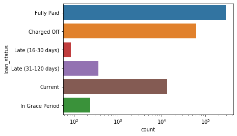

```python
# Visualize distribution of Predictor variable classes
def categorical_summarized(dataframe, x=None, y=None, hue=None, palette='Set1', verbose=True):
    '''
    Helper function that gives a quick summary of a given column of categorical data
    Arguments
    =========
    dataframe: pandas dataframe
    x: str. horizontal axis to plot the labels of categorical data, y would be the count
    y: str. vertical axis to plot the labels of categorical data, x would be the count
    hue: str. if you want to compare it another variable (usually the target variable)
    palette: array-like. Colour of the plot
    Returns
    =======
    Quick Stats of the data and also the count plot
    '''
    if x == None:
        column_interested = y
    else:
        column_interested = x
    series = dataframe[column_interested]
    print(series.describe())
    print('mode: ', series.mode())
    if verbose:
        print('='*80)
        print(series.value_counts())

    p = sns.countplot(x=x, y=y, hue=hue, data=dataframe, palette=palette)
    p.set(xscale="log")
    plt.show()

# Target Variable: Survival
c_palette = ['tab:blue', 'tab:orange', 'tab:red', 'tab:purple', 'tab:brown', 'tab:green', 'tab:cyan', 'tab:gray', 'tab:olive']
# Allowed colors are
# 'tab:blue', 'tab:orange', 'tab:green', 'tab:red', 'tab:purple', 'tab:brown', 'tab:pink', 'tab:gray', 'tab:olive', 'tab:cyan'
categorical_summarized(dataset, y = 'loan_status', palette=c_palette)
```

### Cleaned dataset has ~356K loans x 41 variables (including loan_status output variable which is transformed to binary 0/1)

```python
data_with_loanstatus_sliced = reduced_dataset[(reduced_dataset['loan_status']=="Fully Paid") | (reduced_dataset['loan_status']=="Charged Off") | (reduced_dataset['loan_status']=="Default")]
print("Current shape of dataset :",data_with_loanstatus_sliced.shape)

categorical_cols_to_delete = ["delinq_2yrs",  "chargeoff_within_12_mths","delinq_amnt", "earliest_cr_line", "delinq_amnt", "purpose", "zip_code",
"chargeoff_within_12_mths",  "issue_d", "inq_last_6mths", "last_credit_pull_d"] #deleting some more columns "purpose", "zip_code", "num_accts_ever_120_pd"
data_with_loanstatus_sliced = data_with_loanstatus_sliced.drop(labels = categorical_cols_to_delete, axis = 1)


di = {"Fully Paid":0, "Charged Off":1, "Default":1}   #converting target variable to boolean
dataset_with_binarytarget= data_with_loanstatus_sliced.replace({"loan_status": di})
display(dataset_with_binarytarget['loan_status'].value_counts())
display(dataset_with_binarytarget.shape)
display(dataset_with_binarytarget.head())


dataset_with_binarytarget.to_csv("cleaned_dataset.csv", index=False)
```

```
Current shape of dataset : (356261, 50)
```

```
0    294183
1     62078
Name: loan_status, dtype: int64
```

```
(356261, 41)
```

|  | loan_amnt | term | int_rate | grade | emp_length | home_ownership | annual_inc | loan_status | addr_state | dti | open_acc | pub_rec | revol_bal | revol_util | total_acc | recoveries | collections_12_mths_ex_med | application_type | acc_now_delinq | tot_coll_amt | tot_cur_bal | acc_open_past_24mths | bc_open_to_buy | mo_sin_old_il_acct | mo_sin_old_rev_tl_op | mo_sin_rcnt_rev_tl_op | mo_sin_rcnt_tl | mort_acc | mths_since_recent_bc | … |
| --- | --- | --- | --- | --- | --- | --- | --- | --- | --- | --- | --- | --- | --- | --- | --- | --- | --- | --- | --- | --- | --- | --- | --- | --- | --- | --- | --- | --- | --- | --- |
| 1675675 | 12000 | 36 months | 6.6200 | A | 10+ years | MORTGAGE | 105000.0000 | 0 | CT | 14.0500 | 12.0000 | 0.0000 | 13168 | 21.6000 | 22.0000 | 0.0000 | 0.0000 | Individual | 0.0000 | 0.0000 | 267646.0000 | 4.0000 | 39432.0000 | 146.0000 | 237.0000 | 20.0000 | 3.0000 | 4.0000 | 20.0000 | … |
| 1675676 | 28000 | 36 months | 7.6200 | A | 5 years | MORTGAGE | 325000.0000 | 0 | CA | 18.5500 | 15.0000 | 0.0000 | 29581 | 54.6000 | 31.0000 | 0.0000 | 0.0000 | Individual | 0.0000 | 0.0000 | 799592.0000 | 6.0000 | 13901.0000 | 125.0000 | 229.0000 | 5.0000 | 2.0000 | 5.0000 | 5.0000 | … |
| 1675677 | 27050 | 36 months | 10.9900 | B | 10+ years | OWN | 55000.0000 | 0 | MI | 22.8700 | 14.0000 | 0.0000 | 36638 | 61.2000 | 27.0000 | 0.0000 | 0.0000 | Individual | 0.0000 | 0.0000 | 114834.0000 | 3.0000 | 16473.0000 | 117.0000 | 326.0000 | 16.0000 | 6.0000 | 4.0000 | 16.0000 | … |
| 1675678 | 12000 | 36 months | 11.9900 | B | 10+ years | MORTGAGE | 130000.0000 | 0 | CO | 13.0300 | 9.0000 | 0.0000 | 10805 | 67.0000 | 19.0000 | 0.0000 | 0.0000 | Individual | 0.0000 | 0.0000 | 327264.0000 | 4.0000 | 3567.0000 | 173.0000 | 193.0000 | 4.0000 | 4.0000 | 3.0000 | 85.0000 | … |
| 1675679 | 12000 | 36 months | 7.6200 | A | 3 years | MORTGAGE | 96500.0000 | 0 | TX | 12.6100 | 17.0000 | 0.0000 | 13248 | 55.7000 | 30.0000 | 0.0000 | 0.0000 | Individual | 0.0000 | 0.0000 | 200314.0000 | 4.0000 | 2441.0000 | 123.0000 | 118.0000 | 10.0000 | 9.0000 | 1.0000 | 10.0000 | … |

## Setup data pipeline and data transformations

### Handle nominal categorical variables by creating dummy or indicator variables (0/1)

### Ordinal variables are mapped using their frequency distribution

### To avoid distortions from different scale of values for variables, normalize all variables to create a Z-score

### Ignore variables with little to no variability

### Save data pipleine and transformed dataset

```python
from pycaret.classification import *
dataset_with_binarytarget = pd.read_csv("cleaned_dataset.csv")
print("Cleaned Dataset Shape: ", dataset_with_binarytarget.shape)
lc_data_pipeline_sampled = setup(data = dataset_with_binarytarget, target = 'loan_status', session_id=123, train_size=0.8, # sampling=False,
                         ordinal_features = {
                                 'grade' : ['G', 'F', 'E', 'D', 'C', 'B', 'A'],
                                 'home_ownership' : ['ANY', 'RENT','MORTGAGE', 'OWN'], #'NONE',  'OTHER',
                                 'emp_length' : ['< 1 year', '1 year', '2 years', '3 years', '4 years', '5 years', '6 years', '7 years', '8 years', '9 years', '10+ years']
                         },
                         high_cardinality_features= [
                             'addr_state'
#                              , 'zip_code'
                         ],
                         normalize=True,
#                          transformation=True,
                         ignore_low_variance=True,
#                          combine_rare_levels=True,
                         remove_multicollinearity=True
#                          , profile=True
                        )
# display(lc_data_pipeline)
```

```
Setup Succesfully Completed!
```

|  | Description | Value |
| --- | --- | --- |
| 0 | session_id | 123 |
| 1 | Target Type | Binary |
| 2 | Label Encoded | None |
| 3 | Original Data | (356261, 41) |
| 4 | Missing Values | True |
| 5 | Numeric Features | 31 |
| 6 | Categorical Features | 9 |
| 7 | Ordinal Features | True |
| 8 | High Cardinality Features | True |
| 9 | High Cardinality Method | frequency |
| 10 | Sampled Data | (106878, 41) |
| 11 | Transformed Train Set | (85502, 30) |
| 12 | Transformed Test Set | (21376, 30) |
| 13 | Numeric Imputer | mean |
| 14 | Categorical Imputer | constant |
| 15 | Normalize | True |
| 16 | Normalize Method | zscore |
| 17 | Transformation | False |
| 18 | Transformation Method | None |
| 19 | PCA | False |
| 20 | PCA Method | None |
| 21 | PCA Components | None |
| 22 | Ignore Low Variance | True |
| 23 | Combine Rare Levels | False |
| 24 | Rare Level Threshold | None |
| 25 | Numeric Binning | False |
| 26 | Remove Outliers | False |
| 27 | Outliers Threshold | None |
| 28 | Remove Multicollinearity | True |
| 29 | Multicollinearity Threshold | 0.9000 |
| 30 | Clustering | False |
| 31 | Clustering Iteration | None |
| 32 | Polynomial Features | False |
| 33 | Polynomial Degree | None |
| 34 | Trignometry Features | False |
| 35 | Polynomial Threshold | None |
| 36 | Group Features | False |
| 37 | Feature Selection | False |
| 38 | Features Selection Threshold | None |
| 39 | Feature Interaction | False |
| 40 | Feature Ratio | False |
| 41 | Interaction Threshold | None |

```python
# display(lc_data_pipeline_sampled)

lcdataset_dmp_file = open('lc2yrdata_setup_pipeline_sampled', 'ab')
# source, destination
pickle.dump(lc_data_pipeline_sampled, lcdataset_dmp_file)
lcdataset_dmp_file.close()
```

```python
# Final Dataset
final_sampled_dataset = lc_data_pipeline_sampled[0]
training_set = lc_data_pipeline_sampled[1]
testing_set = lc_data_pipeline_sampled[1]
print("Final DataSet")
display(final_sampled_dataset)
```

```
Final DataSet
```

|  | loan_amnt | grade | emp_length | home_ownership | annual_inc | addr_state | dti | open_acc | pub_rec | revol_bal | ... | mort_acc | mths_since_recent_bc | num_accts_ever_120_pd | num_actv_bc_tl | num_il_tl | num_rev_accts | num_tl_op_past_12m | pub_rec_bankruptcies | total_il_high_credit_limit | term_ 36 months |
| --- | --- | --- | --- | --- | --- | --- | --- | --- | --- | --- | --- | --- | --- | --- | --- | --- | --- | --- | --- | --- | --- |
| 0 | -0.3147 | 1.4107 | 1.0940 | 0.4765 | 0.5865 | -0.8443 | -0.4591 | 0.1089 | -0.3436 | -0.1548 | ... | 0.9863 | -0.1618 | -0.3781 | -0.8041 | 0.1046 | -0.7900 | 0.0427 | -0.3526 | 0.1268 | 1.0000 |
| 1 | 1.6162 | 1.4107 | -0.2036 | 0.4765 | 4.7519 | 2.0428 | 0.1130 | 0.7033 | -0.3436 | 0.6252 | ... | 1.4461 | -0.6660 | -0.3781 | 0.1394 | 0.3875 | -0.0235 | 1.9476 | -0.3526 | 3.9946 | 1.0000 |
| 2 | 1.5016 | 0.6432 | 1.0940 | 2.0682 | -0.3601 | -0.6079 | 0.6623 | 0.5052 | -0.3436 | 0.9605 | ... | 0.9863 | -0.2963 | -0.3781 | -0.8041 | -0.0369 | -0.0235 | -0.5922 | -0.3526 | -0.1173 | 1.0000 |
| 3 | -0.3147 | 0.6432 | 1.0940 | 0.4765 | 1.0599 | -0.7000 | -0.5888 | -0.4856 | -0.3436 | -0.2671 | ... | 0.5266 | 2.0232 | -0.3781 | -0.3324 | -0.0369 | -0.9178 | 0.6777 | -0.3526 | 0.5014 | 1.0000 |
| 4 | -0.3147 | 1.4107 | -0.7227 | 0.4765 | 0.4256 | 0.5383 | -0.6422 | 1.0996 | -0.3436 | -0.1510 | ... | -0.3929 | -0.4979 | -0.3781 | 0.1394 | 0.9533 | -0.1513 | 0.6777 | -0.3526 | 0.3941 | 1.0000 |
| ... | ... | ... | ... | ... | ... | ... | ... | ... | ... | ... | ... | ... | ... | ... | ... | ... | ... | ... | ... | ... | ... |
| 356256 | 0.4577 | -0.1244 | -0.4632 | 0.4765 | 0.6812 | 0.5383 | 0.2783 | 1.2978 | -0.3436 | 0.3223 | ... | 0.9863 | 1.4854 | -0.3781 | 0.6111 | 1.6606 | -0.4068 | -0.5922 | -0.3526 | 3.0663 | 0.0000 |
| 356257 | 0.8921 | -0.8919 | 1.0940 | 0.4765 | 0.0753 | -0.8178 | 0.1003 | 1.2978 | 1.4438 | 0.0861 | ... | 1.4461 | -0.2626 | -0.3781 | -0.3324 | -0.0369 | 0.1043 | 0.0427 | 2.4142 | 0.0409 | 0.0000 |
| 356258 | -1.5215 | 1.4107 | -0.7227 | 2.0682 | 0.1700 | 2.0428 | -1.5601 | 1.8923 | -0.3436 | -0.2386 | ... | 0.0668 | -0.6660 | -0.3781 | -0.8041 | 0.1046 | 0.1043 | 1.3126 | -0.3526 | -0.0131 | 1.0000 |
| 356259 | 0.7353 | -0.8919 | 0.3154 | 0.4765 | -0.5305 | -0.4518 | 1.0157 | 1.2978 | -0.3436 | -0.4627 | ... | 0.5266 | 2.2921 | -0.3781 | -1.2758 | 4.2067 | -1.6843 | -1.2272 | -0.3526 | 1.1499 | 0.0000 |
| 356260 | -0.5560 | -0.8919 | 1.0940 | 0.4765 | -0.5305 | 2.0428 | 0.6508 | -1.0801 | -0.3436 | -0.2424 | ... | 0.0668 | -0.6996 | -0.3781 | -0.8041 | -0.7441 | 0.2320 | 0.0427 | -0.3526 | 0.6973 | 1.0000 |

356261 rows × 30 columns

```python
lc_data_pipeline_loaded = pickle.load( open( "lc2yrdata_setup_pipeline_norm", "rb" ) )
```

## Compare & Tune Models with Training Data: Logistic regression (LR/GLM), K-nearest neighbors (KNN), Random Forest (RF), Support Vector Machines (SVM), Decision Trees (DT), and Mullti-layer Perceptron (MLP)

```python
comps = compare_models(blacklist=['xgboost', 'ada', 'qda', 'lda', 'nb', 'ridge', 'gbc', 'et', 'lightgbm', 'catboost'])
# Logistic Regression	‘lr’
```

```python
comps
```

|  | Model | Accuracy | AUC | Recall | Prec. | F1 | Kappa |
| --- | --- | --- | --- | --- | --- | --- | --- |
| 0 | Random Forest Classifier | 0.9640 | 0.9191 | 0.7958 | 0.9973 | 0.8852 | 0.8642 |
| 1 | Logistic Regression | 0.9492 | 0.9222 | 0.7084 | 0.9999 | 0.8292 | 0.8004 |
| 2 | SVM - Linear Kernel | 0.9489 | 0.0000 | 0.7071 | 0.9999 | 0.8283 | 0.7994 |
| 3 | Decision Tree Classifier | 0.9274 | 0.8840 | 0.8173 | 0.7775 | 0.7968 | 0.7527 |
| 4 | K Neighbors Classifier | 0.8762 | 0.7480 | 0.3402 | 0.8699 | 0.4891 | 0.4336 |

## Tuning LR Model

```python
# lr = tune_model('lr')
tuned_lr = tune_model('lr')

# takes 2 min

# dataset_with_binarytarget.describe(include='all')
```

|  | Accuracy | AUC | Recall | Prec. | F1 | Kappa |
| --- | --- | --- | --- | --- | --- | --- |
| 0 | 0.9492 | 0.9203 | 0.7087 | 1.0000 | 0.8295 | 0.8007 |
| 1 | 0.9508 | 0.9261 | 0.7174 | 1.0000 | 0.8355 | 0.8075 |
| 2 | 0.9499 | 0.9229 | 0.7126 | 1.0000 | 0.8322 | 0.8037 |
| 3 | 0.9475 | 0.9164 | 0.6985 | 1.0000 | 0.8225 | 0.7928 |
| 4 | 0.9512 | 0.9287 | 0.7201 | 1.0000 | 0.8373 | 0.8095 |
| 5 | 0.9484 | 0.9208 | 0.7040 | 1.0000 | 0.8263 | 0.7971 |
| 6 | 0.9498 | 0.9244 | 0.7121 | 1.0000 | 0.8318 | 0.8033 |
| 7 | 0.9561 | 0.9339 | 0.7483 | 1.0000 | 0.8560 | 0.8308 |
| 8 | 0.9487 | 0.9166 | 0.7054 | 1.0000 | 0.8272 | 0.7981 |
| 9 | 0.9480 | 0.9195 | 0.7020 | 0.9990 | 0.8246 | 0.7951 |
| Mean | 0.9500 | 0.9230 | 0.7129 | 0.9999 | 0.8323 | 0.8039 |
| SD | 0.0023 | 0.0052 | 0.0134 | 0.0003 | 0.0091 | 0.0103 |

```python
evaluate_model(tuned_lr)
```

```python
# # Area Under the Curve	‘auc’
# p1 = plot_model(tuned_lr, 'auc')
# # Discrimination Threshold	‘threshold’
# # plot_model(lr, 'threshold')
```

```python
# # Precision Recall Curve	‘pr’
# p2 = plot_model(tuned_lr, 'pr')
```

```python
# # Confusion Matrix	‘confusion_matrix’
# p3 = plot_model(tuned_lr, 'confusion_matrix')
```

```python
# # Validation Curve	‘vc’
# p4 = plot_model(tuned_lr, 'calibration')
# # Dimension Learning	‘dimension’
# # Feature Importance	‘feature’
# # Model Hyperparameter	‘parameter’
# # p5 = plot_model(lr, 'parameter')
```

```python
# # Class Prediction Error	‘error’
# p5 = plot_model(tuned_lr, 'error')
# # Classification Report	‘class_report’
# # Decision Boundary	‘boundary’
# # Recursive Feature Selection	‘rfe’
# # plot_model(lr, 'rfe')

# # Learning Curve	‘learning’
# # p5 = plot_model(lr, 'learning')

# # Manifold Learning	‘manifold’

# # Calibration Curve	‘calibration’
```

```python
# p6 = plot_model(tuned_lr, 'class_report')
# Classification Report	‘class_report’
# Decision Boundary	‘boundary’
# Recursive Feature Selection	‘rfe’
# plot_model(lr, 'rfe')

# Learning Curve	‘learning’
# p5 = plot_model(lr, 'learning')

# Manifold Learning	‘manifold’

# Calibration Curve	‘calibration’
```

```python
# interpret_model(tuned_lr)
```

```python
evaluate_model(tuned_lr)
save_experiment('lr_samp_tuned_2yrLCdata')
```

```
Experiment Succesfully Saved
```

```python
# K Nearest Neighbour	‘knn’
# takes 2 hours+
knn = create_model('knn')
```

|  | Accuracy | AUC | Recall | Prec. | F1 | Kappa |
| --- | --- | --- | --- | --- | --- | --- |
| 0 | 0.8778 | 0.7548 | 0.3430 | 0.8856 | 0.4944 | 0.4400 |
| 1 | 0.8785 | 0.7565 | 0.3490 | 0.8829 | 0.5002 | 0.4455 |
| 2 | 0.8773 | 0.7434 | 0.3418 | 0.8806 | 0.4925 | 0.4377 |
| 3 | 0.8764 | 0.7518 | 0.3459 | 0.8612 | 0.4935 | 0.4374 |
| 4 | 0.8777 | 0.7490 | 0.3463 | 0.8776 | 0.4966 | 0.4416 |
| 5 | 0.8727 | 0.7408 | 0.3248 | 0.8551 | 0.4708 | 0.4147 |
| 6 | 0.8756 | 0.7458 | 0.3430 | 0.8574 | 0.4899 | 0.4335 |
| 7 | 0.8795 | 0.7712 | 0.3470 | 0.9007 | 0.5010 | 0.4474 |
| 8 | 0.8710 | 0.7327 | 0.3215 | 0.8389 | 0.4648 | 0.4076 |
| 9 | 0.8752 | 0.7338 | 0.3396 | 0.8591 | 0.4868 | 0.4305 |
| Mean | 0.8762 | 0.7480 | 0.3402 | 0.8699 | 0.4891 | 0.4336 |
| SD | 0.0025 | 0.0109 | 0.0089 | 0.0175 | 0.0115 | 0.0123 |

```python
evaluate_model(knn)
save_experiment('knn_samp_tuned_2yrLCdata')
```

```
Experiment Succesfully Saved
```

## Tuning Decision Tree Classifier

```python
# Decision Tree	‘dt’
# runs in 1 min
dt = tune_model('dt')
```

|  | Accuracy | AUC | Recall | Prec. | F1 | Kappa |
| --- | --- | --- | --- | --- | --- | --- |
| 0 | 0.9634 | 0.8950 | 0.7899 | 1.0000 | 0.8826 | 0.8613 |
| 1 | 0.9653 | 0.9003 | 0.8007 | 1.0000 | 0.8893 | 0.8690 |
| 2 | 0.9637 | 0.8959 | 0.7918 | 1.0000 | 0.8838 | 0.8627 |
| 3 | 0.9628 | 0.8932 | 0.7864 | 1.0000 | 0.8805 | 0.8588 |
| 4 | 0.9650 | 0.8997 | 0.7993 | 1.0000 | 0.8885 | 0.8680 |
| 5 | 0.9609 | 0.8879 | 0.7758 | 1.0000 | 0.8738 | 0.8511 |
| 6 | 0.9671 | 0.9057 | 0.8114 | 1.0000 | 0.8959 | 0.8766 |
| 7 | 0.9683 | 0.9091 | 0.8181 | 1.0000 | 0.9000 | 0.8814 |
| 8 | 0.9618 | 0.8903 | 0.7805 | 1.0000 | 0.8767 | 0.8545 |
| 9 | 0.9653 | 0.9003 | 0.8007 | 1.0000 | 0.8893 | 0.8690 |
| Mean | 0.9644 | 0.8977 | 0.7955 | 1.0000 | 0.8860 | 0.8652 |
| SD | 0.0022 | 0.0063 | 0.0125 | 0.0000 | 0.0078 | 0.0090 |

```python
evaluate_model(dt)
save_experiment('dt_expt_samp_2yrLCdata')
```

```
Experiment Succesfully Saved
```

```python
# interpret_model(dt, plot='summary')
```

## Tuning SVM model

```python
# SVM (Linear)	‘svm’
# Runs in about 2 min
svm_lin = tune_model('svm')
```

|  | Accuracy | AUC | Recall | Prec. | F1 | Kappa |
| --- | --- | --- | --- | --- | --- | --- |
| 0 | 0.9550 | 0.0000 | 0.7416 | 1.0000 | 0.8516 | 0.8258 |
| 1 | 0.9552 | 0.0000 | 0.7430 | 1.0000 | 0.8525 | 0.8268 |
| 2 | 0.9530 | 0.0000 | 0.7300 | 1.0000 | 0.8439 | 0.8171 |
| 3 | 0.9516 | 0.0000 | 0.7220 | 1.0000 | 0.8385 | 0.8109 |
| 4 | 0.9560 | 0.0000 | 0.7477 | 1.0000 | 0.8556 | 0.8303 |
| 5 | 0.9524 | 0.0000 | 0.7268 | 1.0000 | 0.8418 | 0.8146 |
| 6 | 0.9550 | 0.0000 | 0.7416 | 1.0000 | 0.8516 | 0.8258 |
| 7 | 0.9592 | 0.0000 | 0.7658 | 1.0000 | 0.8674 | 0.8437 |
| 8 | 0.9524 | 0.0000 | 0.7268 | 1.0000 | 0.8418 | 0.8146 |
| 9 | 0.9524 | 0.0000 | 0.7268 | 1.0000 | 0.8418 | 0.8146 |
| Mean | 0.9542 | 0.0000 | 0.7372 | 1.0000 | 0.8487 | 0.8224 |
| SD | 0.0022 | 0.0000 | 0.0127 | 0.0000 | 0.0083 | 0.0095 |

```python
evaluate_model(svm_lin)
save_experiment('svm_lin_expt_samp_2yrLCdata')
```

```
Experiment Succesfully Saved
```

## Tuning MLP (ANN) Model

```python
# Multi Level Pmlp_nneptron	‘mlp’
# takes 75 min for hyperparam tuning and 50 min for 10-fold validation
mlp_nn = tune_model('mlp')
```

|  | Accuracy | AUC | Recall | Prec. | F1 | Kappa |
| --- | --- | --- | --- | --- | --- | --- |
| 0 | 0.9457 | 0.9205 | 0.6886 | 1.0000 | 0.8156 | 0.7850 |
| 1 | 0.9474 | 0.9228 | 0.6987 | 0.9990 | 0.8223 | 0.7925 |
| 2 | 0.9457 | 0.9221 | 0.6884 | 1.0000 | 0.8154 | 0.7849 |
| 3 | 0.9440 | 0.9145 | 0.6783 | 1.0000 | 0.8083 | 0.7769 |
| 4 | 0.9484 | 0.9271 | 0.7040 | 1.0000 | 0.8263 | 0.7971 |
| 5 | 0.9453 | 0.9179 | 0.6866 | 0.9990 | 0.8138 | 0.7830 |
| 6 | 0.9462 | 0.9206 | 0.6913 | 1.0000 | 0.8175 | 0.7871 |
| 7 | 0.9516 | 0.9327 | 0.7221 | 1.0000 | 0.8387 | 0.8110 |
| 8 | 0.9447 | 0.9132 | 0.6832 | 0.9990 | 0.8115 | 0.7804 |
| 9 | 0.9446 | 0.9179 | 0.6826 | 0.9990 | 0.8110 | 0.7799 |
| Mean | 0.9464 | 0.9209 | 0.6924 | 0.9996 | 0.8180 | 0.7878 |
| SD | 0.0022 | 0.0055 | 0.0123 | 0.0005 | 0.0085 | 0.0096 |

```python
evaluate_model(mlp_nn)
save_experiment('mlp_nn_expt_samp_2yrLCdata')
```

```
Experiment Succesfully Saved
```

```python
# Ridge Classifier	‘ridge’
# run time: ~ 22 min
# Random Forest	‘rf’
rf = tune_model('rf')
```

|  | Accuracy | AUC | Recall | Prec. | F1 | Kappa |
| --- | --- | --- | --- | --- | --- | --- |
| 0 | 0.9633 | 0.9386 | 0.7893 | 1.0000 | 0.8822 | 0.8608 |
| 1 | 0.9653 | 0.9445 | 0.8007 | 1.0000 | 0.8893 | 0.8690 |
| 2 | 0.9637 | 0.9429 | 0.7918 | 1.0000 | 0.8838 | 0.8627 |
| 3 | 0.9628 | 0.9388 | 0.7864 | 1.0000 | 0.8805 | 0.8588 |
| 4 | 0.9649 | 0.9453 | 0.7987 | 1.0000 | 0.8881 | 0.8676 |
| 5 | 0.9609 | 0.9359 | 0.7758 | 1.0000 | 0.8738 | 0.8511 |
| 6 | 0.9671 | 0.9429 | 0.8114 | 1.0000 | 0.8959 | 0.8766 |
| 7 | 0.9683 | 0.9524 | 0.8181 | 1.0000 | 0.9000 | 0.8814 |
| 8 | 0.9618 | 0.9394 | 0.7805 | 1.0000 | 0.8767 | 0.8545 |
| 9 | 0.9653 | 0.9403 | 0.8007 | 1.0000 | 0.8893 | 0.8690 |
| Mean | 0.9643 | 0.9421 | 0.7953 | 1.0000 | 0.8860 | 0.8651 |
| SD | 0.0022 | 0.0044 | 0.0125 | 0.0000 | 0.0078 | 0.0090 |

```python
evaluate_model(rf)
save_experiment('rf_expt_samp_2yrLCdata')
```

```
Experiment Succesfully Saved
```

## Variable Importance Plot - Top 10 Features that Influence Loan Default

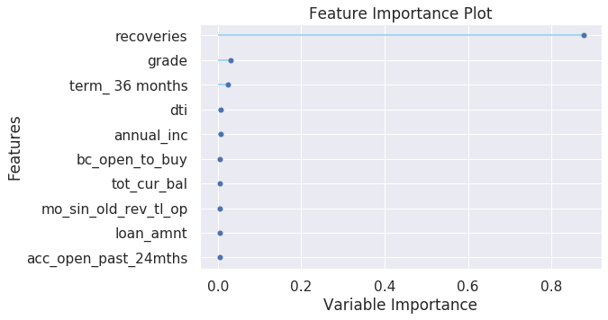

```python
plot_model(rf, "feature")
```

# Comparison of Predictive Power of ML models against Test Data

## LR Model Performance

|  | Model | Accuracy | AUC | Recall | Prec. | F1 | Kappa |
| --- | --- | --- | --- | --- | --- | --- | --- |
| 0 | Logistic Regression | 0.9530 | 0.9298 | 0.7305 | 1.0000 | 0.8442 | 0.8174 |

|  | loan_amnt | grade | emp_length | home_ownership | annual_inc | addr_state | dti | open_acc | pub_rec | revol_bal | ... | num_actv_bc_tl | num_il_tl | num_rev_accts | num_tl_op_past_12m | pub_rec_bankruptcies | total_il_high_credit_limit | term_ 36 months | loan_status | Label | Score |
| --- | --- | --- | --- | --- | --- | --- | --- | --- | --- | --- | --- | --- | --- | --- | --- | --- | --- | --- | --- | --- | --- |
| 0 | -1.1594 | -1.6595 | -1.7608 | -1.1152 | -1.0985 | -0.8443 | 2.0277 | -0.2874 | 1.4438 | -0.4534 | ... | 0.1394 | -1.1685 | 0.9986 | 0.0427 | 2.4142 | -0.9479 | 1.0000 | 1 | 0 | 0.1851 |
| 1 | -0.1970 | -0.8919 | -1.5013 | 0.4765 | -0.8524 | -0.9036 | 2.7270 | -0.8819 | -0.3436 | -0.0761 | ... | -0.3324 | -0.6027 | -1.1733 | -0.5922 | -0.3526 | -0.3740 | 0.0000 | 1 | 1 | 1.0000 |
| 2 | -0.8969 | -1.6595 | -0.9822 | 2.0682 | -1.0607 | -0.9670 | 1.4073 | -0.8819 | -0.3436 | -0.3658 | ... | -0.3324 | -0.8856 | -0.6623 | 0.0427 | -0.3526 | -0.9479 | 1.0000 | 0 | 0 | 0.1120 |
| 3 | -1.3284 | -1.6595 | -0.7227 | -1.1152 | -1.1743 | -0.8919 | 0.2211 | -1.4764 | -0.3436 | -0.5780 | ... | -1.2758 | -1.0270 | -1.4288 | -1.2272 | -0.3526 | -0.9479 | 1.0000 | 0 | 0 | 0.0919 |
| 4 | -0.7370 | 1.4107 | -0.9822 | -1.1152 | -0.6441 | 0.2665 | 0.8670 | -0.8819 | -0.3436 | -0.6496 | ... | -1.2758 | -0.6027 | -1.5566 | -0.5922 | -0.3526 | 1.5207 | 1.0000 | 0 | 0 | 0.0308 |
| ... | ... | ... | ... | ... | ... | ... | ... | ... | ... | ... | ... | ... | ... | ... | ... | ... | ... | ... | ... | ... | ... |
| 21371 | -1.2801 | -0.8919 | 1.0940 | 0.4765 | -0.2087 | -0.6617 | -1.7928 | -0.8819 | -0.3436 | -0.3655 | ... | -0.8041 | -0.8856 | 0.3598 | 1.9476 | -0.3526 | -0.9479 | 1.0000 | 0 | 0 | 0.0386 |
| 21372 | -0.3147 | 1.4107 | 1.0940 | 0.4765 | -0.1519 | 0.2665 | 1.0462 | 0.9015 | 1.4438 | 0.0082 | ... | 1.5545 | -0.1783 | -0.1513 | 0.6777 | 2.4142 | 0.2904 | 1.0000 | 0 | 0 | 0.0456 |
| 21373 | 0.6508 | -0.1244 | 1.0940 | 0.4765 | -0.0761 | 0.5383 | 2.0392 | 2.6849 | -0.3436 | 0.7659 | ... | 1.5545 | -0.1783 | 3.1704 | 1.3126 | -0.3526 | 0.1791 | 1.0000 | 0 | 0 | 0.0737 |
| 21374 | 0.6508 | 1.4107 | -1.5013 | -1.1152 | 0.3215 | 2.0428 | -1.2753 | -0.4856 | -0.3436 | -0.6170 | ... | -0.8041 | -0.8856 | -0.6623 | -1.2272 | -0.3526 | -0.5266 | 1.0000 | 0 | 0 | 0.0142 |
| 21375 | -0.5560 | 0.6432 | -0.4632 | 0.4765 | -0.8335 | -0.9036 | 0.5669 | -0.6838 | -0.3436 | -0.5336 | ... | -0.8041 | -0.7441 | -1.3011 | 0.0427 | -0.3526 | -0.4917 | 1.0000 | 0 | 0 | 0.0522 |

21376 rows × 33 columns

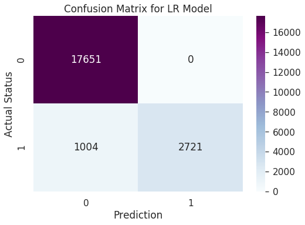

```python
lr_pred = predict_model(tuned_lr)
display(lr_pred)
cm = confusion_matrix(lr_pred['loan_status'], lr_pred['Label'])

# display(cm)

ax= plt.subplot()
sns.heatmap(cm, annot=True, ax = ax, fmt='d', cmap="BuPu"); #annot=True to annotate cells

# labels, title and ticks
ax.set_xlabel('Prediction');ax.set_ylabel('Actual Status');
ax.set_title('Confusion Matrix for LR Model');
ax.xaxis.set_ticklabels(['0', '1']); ax.yaxis.set_ticklabels(['0', '1']);
plt.show()
```

## KNN Model Performance

|  | Model | Accuracy | AUC | Recall | Prec. | F1 | Kappa |
| --- | --- | --- | --- | --- | --- | --- | --- |
| 0 | K Neighbors Classifier | 0.8774 | 0 | 0.3560 | 0.8566 | 0.5029 | 0.4463 |

|  | loan_amnt | grade | emp_length | home_ownership | annual_inc | addr_state | dti | open_acc | pub_rec | revol_bal | ... | num_accts_ever_120_pd | num_actv_bc_tl | num_il_tl | num_rev_accts | num_tl_op_past_12m | pub_rec_bankruptcies | total_il_high_credit_limit | term_ 36 months | loan_status | Label |
| --- | --- | --- | --- | --- | --- | --- | --- | --- | --- | --- | --- | --- | --- | --- | --- | --- | --- | --- | --- | --- | --- |
| 0 | -1.1594 | -1.6595 | -1.7608 | -1.1152 | -1.0985 | -0.8443 | 2.0277 | -0.2874 | 1.4438 | -0.4534 | ... | -0.3781 | 0.1394 | -1.1685 | 0.9986 | 0.0427 | 2.4142 | -0.9479 | 1.0000 | 1 | 0 |
| 1 | -0.1970 | -0.8919 | -1.5013 | 0.4765 | -0.8524 | -0.9036 | 2.7270 | -0.8819 | -0.3436 | -0.0761 | ... | -0.3781 | -0.3324 | -0.6027 | -1.1733 | -0.5922 | -0.3526 | -0.3740 | 0.0000 | 1 | 1 |
| 2 | -0.8969 | -1.6595 | -0.9822 | 2.0682 | -1.0607 | -0.9670 | 1.4073 | -0.8819 | -0.3436 | -0.3658 | ... | -0.3781 | -0.3324 | -0.8856 | -0.6623 | 0.0427 | -0.3526 | -0.9479 | 1.0000 | 0 | 0 |
| 3 | -1.3284 | -1.6595 | -0.7227 | -1.1152 | -1.1743 | -0.8919 | 0.2211 | -1.4764 | -0.3436 | -0.5780 | ... | -0.3781 | -1.2758 | -1.0270 | -1.4288 | -1.2272 | -0.3526 | -0.9479 | 1.0000 | 0 | 0 |
| 4 | -0.7370 | 1.4107 | -0.9822 | -1.1152 | -0.6441 | 0.2665 | 0.8670 | -0.8819 | -0.3436 | -0.6496 | ... | -0.3781 | -1.2758 | -0.6027 | -1.5566 | -0.5922 | -0.3526 | 1.5207 | 1.0000 | 0 | 0 |
| ... | ... | ... | ... | ... | ... | ... | ... | ... | ... | ... | ... | ... | ... | ... | ... | ... | ... | ... | ... | ... | ... |
| 21371 | -1.2801 | -0.8919 | 1.0940 | 0.4765 | -0.2087 | -0.6617 | -1.7928 | -0.8819 | -0.3436 | -0.3655 | ... | 0.4788 | -0.8041 | -0.8856 | 0.3598 | 1.9476 | -0.3526 | -0.9479 | 1.0000 | 0 | 0 |
| 21372 | -0.3147 | 1.4107 | 1.0940 | 0.4765 | -0.1519 | 0.2665 | 1.0462 | 0.9015 | 1.4438 | 0.0082 | ... | -0.3781 | 1.5545 | -0.1783 | -0.1513 | 0.6777 | 2.4142 | 0.2904 | 1.0000 | 0 | 0 |
| 21373 | 0.6508 | -0.1244 | 1.0940 | 0.4765 | -0.0761 | 0.5383 | 2.0392 | 2.6849 | -0.3436 | 0.7659 | ... | -0.3781 | 1.5545 | -0.1783 | 3.1704 | 1.3126 | -0.3526 | 0.1791 | 1.0000 | 0 | 0 |
| 21374 | 0.6508 | 1.4107 | -1.5013 | -1.1152 | 0.3215 | 2.0428 | -1.2753 | -0.4856 | -0.3436 | -0.6170 | ... | -0.3781 | -0.8041 | -0.8856 | -0.6623 | -1.2272 | -0.3526 | -0.5266 | 1.0000 | 0 | 0 |
| 21375 | -0.5560 | 0.6432 | -0.4632 | 0.4765 | -0.8335 | -0.9036 | 0.5669 | -0.6838 | -0.3436 | -0.5336 | ... | 0.4788 | -0.8041 | -0.7441 | -1.3011 | 0.0427 | -0.3526 | -0.4917 | 1.0000 | 0 | 0 |

21376 rows × 32 columns

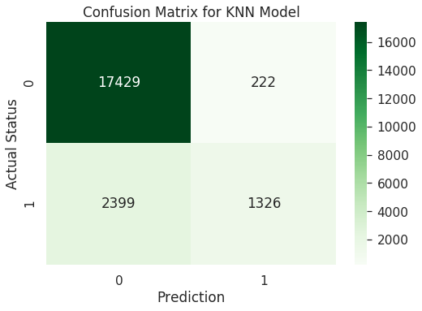

```python
knn_pred = predict_model(knn)
display(knn_pred)
cm = confusion_matrix(knn_pred['loan_status'], knn_pred['Label'])

# display(cm)

ax= plt.subplot()
sns.heatmap(cm, annot=True, ax = ax, fmt='d', cmap="Greens"); #annot=True to annotate cells

# labels, title and ticks
ax.set_xlabel('Prediction');ax.set_ylabel('Actual Status');
ax.set_title('Confusion Matrix for KNN Model');
ax.xaxis.set_ticklabels(['0', '1']); ax.yaxis.set_ticklabels(['0', '1']);
plt.show()
```

## SVM Model Performance

|  | Model | Accuracy | AUC | Recall | Prec. | F1 | Kappa |
| --- | --- | --- | --- | --- | --- | --- | --- |
| 0 | SVM - Linear Kernel | 0.9572 | 0 | 0.7546 | 1.0000 | 0.8602 | 0.8355 |

|  | loan_amnt | grade | emp_length | home_ownership | annual_inc | addr_state | dti | open_acc | pub_rec | revol_bal | ... | num_accts_ever_120_pd | num_actv_bc_tl | num_il_tl | num_rev_accts | num_tl_op_past_12m | pub_rec_bankruptcies | total_il_high_credit_limit | term_ 36 months | loan_status | Label |
| --- | --- | --- | --- | --- | --- | --- | --- | --- | --- | --- | --- | --- | --- | --- | --- | --- | --- | --- | --- | --- | --- |
| 0 | -1.1594 | -1.6595 | -1.7608 | -1.1152 | -1.0985 | -0.8443 | 2.0277 | -0.2874 | 1.4438 | -0.4534 | ... | -0.3781 | 0.1394 | -1.1685 | 0.9986 | 0.0427 | 2.4142 | -0.9479 | 1.0000 | 1 | 0 |
| 1 | -0.1970 | -0.8919 | -1.5013 | 0.4765 | -0.8524 | -0.9036 | 2.7270 | -0.8819 | -0.3436 | -0.0761 | ... | -0.3781 | -0.3324 | -0.6027 | -1.1733 | -0.5922 | -0.3526 | -0.3740 | 0.0000 | 1 | 1 |
| 2 | -0.8969 | -1.6595 | -0.9822 | 2.0682 | -1.0607 | -0.9670 | 1.4073 | -0.8819 | -0.3436 | -0.3658 | ... | -0.3781 | -0.3324 | -0.8856 | -0.6623 | 0.0427 | -0.3526 | -0.9479 | 1.0000 | 0 | 0 |
| 3 | -1.3284 | -1.6595 | -0.7227 | -1.1152 | -1.1743 | -0.8919 | 0.2211 | -1.4764 | -0.3436 | -0.5780 | ... | -0.3781 | -1.2758 | -1.0270 | -1.4288 | -1.2272 | -0.3526 | -0.9479 | 1.0000 | 0 | 0 |
| 4 | -0.7370 | 1.4107 | -0.9822 | -1.1152 | -0.6441 | 0.2665 | 0.8670 | -0.8819 | -0.3436 | -0.6496 | ... | -0.3781 | -1.2758 | -0.6027 | -1.5566 | -0.5922 | -0.3526 | 1.5207 | 1.0000 | 0 | 0 |
| ... | ... | ... | ... | ... | ... | ... | ... | ... | ... | ... | ... | ... | ... | ... | ... | ... | ... | ... | ... | ... | ... |
| 21371 | -1.2801 | -0.8919 | 1.0940 | 0.4765 | -0.2087 | -0.6617 | -1.7928 | -0.8819 | -0.3436 | -0.3655 | ... | 0.4788 | -0.8041 | -0.8856 | 0.3598 | 1.9476 | -0.3526 | -0.9479 | 1.0000 | 0 | 0 |
| 21372 | -0.3147 | 1.4107 | 1.0940 | 0.4765 | -0.1519 | 0.2665 | 1.0462 | 0.9015 | 1.4438 | 0.0082 | ... | -0.3781 | 1.5545 | -0.1783 | -0.1513 | 0.6777 | 2.4142 | 0.2904 | 1.0000 | 0 | 0 |
| 21373 | 0.6508 | -0.1244 | 1.0940 | 0.4765 | -0.0761 | 0.5383 | 2.0392 | 2.6849 | -0.3436 | 0.7659 | ... | -0.3781 | 1.5545 | -0.1783 | 3.1704 | 1.3126 | -0.3526 | 0.1791 | 1.0000 | 0 | 0 |
| 21374 | 0.6508 | 1.4107 | -1.5013 | -1.1152 | 0.3215 | 2.0428 | -1.2753 | -0.4856 | -0.3436 | -0.6170 | ... | -0.3781 | -0.8041 | -0.8856 | -0.6623 | -1.2272 | -0.3526 | -0.5266 | 1.0000 | 0 | 0 |
| 21375 | -0.5560 | 0.6432 | -0.4632 | 0.4765 | -0.8335 | -0.9036 | 0.5669 | -0.6838 | -0.3436 | -0.5336 | ... | 0.4788 | -0.8041 | -0.7441 | -1.3011 | 0.0427 | -0.3526 | -0.4917 | 1.0000 | 0 | 0 |

21376 rows × 32 columns

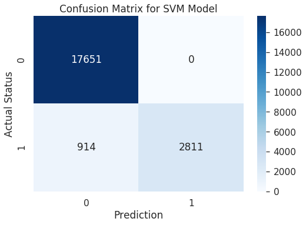

```python
svm_lin_pred = predict_model(svm_lin)
display(svm_lin_pred)
cm = confusion_matrix(svm_lin_pred['loan_status'], svm_lin_pred['Label'])

# display(cm)

ax= plt.subplot()
sns.heatmap(cm, annot=True, ax = ax, fmt='d', cmap="Blues"); #annot=True to annotate cells

# labels, title and ticks
ax.set_xlabel('Prediction');ax.set_ylabel('Actual Status');
ax.set_title('Confusion Matrix for SVM Model');
ax.xaxis.set_ticklabels(['0', '1']); ax.yaxis.set_ticklabels(['0', '1']);
plt.show()
```

## MLP (ANN) Model Performance

|  | Model | Accuracy | AUC | Recall | Prec. | F1 | Kappa |
| --- | --- | --- | --- | --- | --- | --- | --- |
| 0 | MLP Classifier | 0.9492 | 0.9295 | 0.7093 | 0.9989 | 0.8295 | 0.8007 |

|  | loan_amnt | grade | emp_length | home_ownership | annual_inc | addr_state | dti | open_acc | pub_rec | revol_bal | ... | num_actv_bc_tl | num_il_tl | num_rev_accts | num_tl_op_past_12m | pub_rec_bankruptcies | total_il_high_credit_limit | term_ 36 months | loan_status | Label | Score |
| --- | --- | --- | --- | --- | --- | --- | --- | --- | --- | --- | --- | --- | --- | --- | --- | --- | --- | --- | --- | --- | --- |
| 0 | -1.1594 | -1.6595 | -1.7608 | -1.1152 | -1.0985 | -0.8443 | 2.0277 | -0.2874 | 1.4438 | -0.4534 | ... | 0.1394 | -1.1685 | 0.9986 | 0.0427 | 2.4142 | -0.9479 | 1.0000 | 1 | 0 | 0.2568 |
| 1 | -0.1970 | -0.8919 | -1.5013 | 0.4765 | -0.8524 | -0.9036 | 2.7270 | -0.8819 | -0.3436 | -0.0761 | ... | -0.3324 | -0.6027 | -1.1733 | -0.5922 | -0.3526 | -0.3740 | 0.0000 | 1 | 1 | 1.0000 |
| 2 | -0.8969 | -1.6595 | -0.9822 | 2.0682 | -1.0607 | -0.9670 | 1.4073 | -0.8819 | -0.3436 | -0.3658 | ... | -0.3324 | -0.8856 | -0.6623 | 0.0427 | -0.3526 | -0.9479 | 1.0000 | 0 | 0 | 0.1395 |
| 3 | -1.3284 | -1.6595 | -0.7227 | -1.1152 | -1.1743 | -0.8919 | 0.2211 | -1.4764 | -0.3436 | -0.5780 | ... | -1.2758 | -1.0270 | -1.4288 | -1.2272 | -0.3526 | -0.9479 | 1.0000 | 0 | 0 | 0.0993 |
| 4 | -0.7370 | 1.4107 | -0.9822 | -1.1152 | -0.6441 | 0.2665 | 0.8670 | -0.8819 | -0.3436 | -0.6496 | ... | -1.2758 | -0.6027 | -1.5566 | -0.5922 | -0.3526 | 1.5207 | 1.0000 | 0 | 0 | 0.0248 |
| ... | ... | ... | ... | ... | ... | ... | ... | ... | ... | ... | ... | ... | ... | ... | ... | ... | ... | ... | ... | ... | ... |
| 21371 | -1.2801 | -0.8919 | 1.0940 | 0.4765 | -0.2087 | -0.6617 | -1.7928 | -0.8819 | -0.3436 | -0.3655 | ... | -0.8041 | -0.8856 | 0.3598 | 1.9476 | -0.3526 | -0.9479 | 1.0000 | 0 | 0 | 0.0655 |
| 21372 | -0.3147 | 1.4107 | 1.0940 | 0.4765 | -0.1519 | 0.2665 | 1.0462 | 0.9015 | 1.4438 | 0.0082 | ... | 1.5545 | -0.1783 | -0.1513 | 0.6777 | 2.4142 | 0.2904 | 1.0000 | 0 | 0 | 0.0405 |
| 21373 | 0.6508 | -0.1244 | 1.0940 | 0.4765 | -0.0761 | 0.5383 | 2.0392 | 2.6849 | -0.3436 | 0.7659 | ... | 1.5545 | -0.1783 | 3.1704 | 1.3126 | -0.3526 | 0.1791 | 1.0000 | 0 | 0 | 0.0782 |
| 21374 | 0.6508 | 1.4107 | -1.5013 | -1.1152 | 0.3215 | 2.0428 | -1.2753 | -0.4856 | -0.3436 | -0.6170 | ... | -0.8041 | -0.8856 | -0.6623 | -1.2272 | -0.3526 | -0.5266 | 1.0000 | 0 | 0 | 0.0138 |
| 21375 | -0.5560 | 0.6432 | -0.4632 | 0.4765 | -0.8335 | -0.9036 | 0.5669 | -0.6838 | -0.3436 | -0.5336 | ... | -0.8041 | -0.7441 | -1.3011 | 0.0427 | -0.3526 | -0.4917 | 1.0000 | 0 | 0 | 0.0518 |

21376 rows × 33 columns

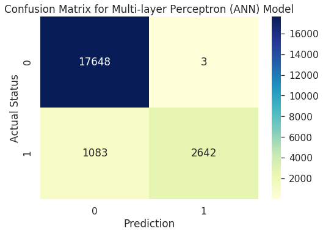

```python
mlp_nn_pred = predict_model(mlp_nn)
display(mlp_nn_pred)
cm = confusion_matrix(mlp_nn_pred['loan_status'], mlp_nn_pred['Label'])

# display(cm)

ax= plt.subplot()
sns.heatmap(cm, annot=True, ax = ax, fmt='d', cmap="YlGnBu"); #annot=True to annotate cells

# labels, title and ticks
ax.set_xlabel('Prediction');ax.set_ylabel('Actual Status');
ax.set_title('Confusion Matrix for Multi-layer Perceptron (ANN) Model');
ax.xaxis.set_ticklabels(['0', '1']); ax.yaxis.set_ticklabels(['0', '1']);
plt.show()
```

## RF Model Performance

|  | Model | Accuracy | AUC | Recall | Prec. | F1 | Kappa |
| --- | --- | --- | --- | --- | --- | --- | --- |
| 0 | Random Forest Classifier | 0.9671 | 0.9495 | 0.8110 | 1.0000 | 0.8956 | 0.8763 |

|  | loan_amnt | grade | emp_length | home_ownership | annual_inc | addr_state | dti | open_acc | pub_rec | revol_bal | ... | num_actv_bc_tl | num_il_tl | num_rev_accts | num_tl_op_past_12m | pub_rec_bankruptcies | total_il_high_credit_limit | term_ 36 months | loan_status | Label | Score |
| --- | --- | --- | --- | --- | --- | --- | --- | --- | --- | --- | --- | --- | --- | --- | --- | --- | --- | --- | --- | --- | --- |
| 0 | -1.1594 | -1.6595 | -1.7608 | -1.1152 | -1.0985 | -0.8443 | 2.0277 | -0.2874 | 1.4438 | -0.4534 | ... | 0.1394 | -1.1685 | 0.9986 | 0.0427 | 2.4142 | -0.9479 | 1.0000 | 1 | 0 | 0.1345 |
| 1 | -0.1970 | -0.8919 | -1.5013 | 0.4765 | -0.8524 | -0.9036 | 2.7270 | -0.8819 | -0.3436 | -0.0761 | ... | -0.3324 | -0.6027 | -1.1733 | -0.5922 | -0.3526 | -0.3740 | 0.0000 | 1 | 1 | 0.9040 |
| 2 | -0.8969 | -1.6595 | -0.9822 | 2.0682 | -1.0607 | -0.9670 | 1.4073 | -0.8819 | -0.3436 | -0.3658 | ... | -0.3324 | -0.8856 | -0.6623 | 0.0427 | -0.3526 | -0.9479 | 1.0000 | 0 | 0 | 0.0971 |
| 3 | -1.3284 | -1.6595 | -0.7227 | -1.1152 | -1.1743 | -0.8919 | 0.2211 | -1.4764 | -0.3436 | -0.5780 | ... | -1.2758 | -1.0270 | -1.4288 | -1.2272 | -0.3526 | -0.9479 | 1.0000 | 0 | 0 | 0.0760 |
| 4 | -0.7370 | 1.4107 | -0.9822 | -1.1152 | -0.6441 | 0.2665 | 0.8670 | -0.8819 | -0.3436 | -0.6496 | ... | -1.2758 | -0.6027 | -1.5566 | -0.5922 | -0.3526 | 1.5207 | 1.0000 | 0 | 0 | 0.0346 |
| ... | ... | ... | ... | ... | ... | ... | ... | ... | ... | ... | ... | ... | ... | ... | ... | ... | ... | ... | ... | ... | ... |
| 21371 | -1.2801 | -0.8919 | 1.0940 | 0.4765 | -0.2087 | -0.6617 | -1.7928 | -0.8819 | -0.3436 | -0.3655 | ... | -0.8041 | -0.8856 | 0.3598 | 1.9476 | -0.3526 | -0.9479 | 1.0000 | 0 | 0 | 0.0649 |
| 21372 | -0.3147 | 1.4107 | 1.0940 | 0.4765 | -0.1519 | 0.2665 | 1.0462 | 0.9015 | 1.4438 | 0.0082 | ... | 1.5545 | -0.1783 | -0.1513 | 0.6777 | 2.4142 | 0.2904 | 1.0000 | 0 | 0 | 0.0438 |
| 21373 | 0.6508 | -0.1244 | 1.0940 | 0.4765 | -0.0761 | 0.5383 | 2.0392 | 2.6849 | -0.3436 | 0.7659 | ... | 1.5545 | -0.1783 | 3.1704 | 1.3126 | -0.3526 | 0.1791 | 1.0000 | 0 | 0 | 0.0712 |
| 21374 | 0.6508 | 1.4107 | -1.5013 | -1.1152 | 0.3215 | 2.0428 | -1.2753 | -0.4856 | -0.3436 | -0.6170 | ... | -0.8041 | -0.8856 | -0.6623 | -1.2272 | -0.3526 | -0.5266 | 1.0000 | 0 | 0 | 0.0188 |
| 21375 | -0.5560 | 0.6432 | -0.4632 | 0.4765 | -0.8335 | -0.9036 | 0.5669 | -0.6838 | -0.3436 | -0.5336 | ... | -0.8041 | -0.7441 | -1.3011 | 0.0427 | -0.3526 | -0.4917 | 1.0000 | 0 | 0 | 0.0505 |

21376 rows × 33 columns

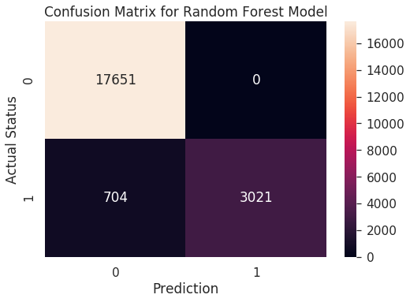

```python
rf_pred = predict_model(rf)
display(rf_pred)
cm = confusion_matrix(rf_pred['loan_status'], rf_pred['Label'])

# display(cm)

ax= plt.subplot()
sns.heatmap(cm, annot=True, ax = ax, fmt='d'); #annot=True to annotate cells

# labels, title and ticks
ax.set_xlabel('Prediction');ax.set_ylabel('Actual Status');
ax.set_title('Confusion Matrix for Random Forest Model');
ax.xaxis.set_ticklabels(['0', '1']); ax.yaxis.set_ticklabels(['0', '1']);
plt.show()
```

## Additional Models: Naive Bayes, AbaBoost, QDA, LDA, XGBoost, LightGBM, CatBoost

### Naive Bayes

```python
# Naives Bayes	‘nb’
# Runs in about 1 min
nb = tune_model('nb')
```

[output not shown]

```python
evaluate_model(nb)
save_experiment('nb_expt_samp_2yrLCdata')
```

```
Experiment Succesfully Saved
```

### Ada Boost

```python
# AdaBoost	‘ada’
# takes ~14 min
ada = tune_model('ada')
```

|  | Accuracy | AUC | Recall | Prec. | F1 | Kappa |
| --- | --- | --- | --- | --- | --- | --- |
| 0 | 0.9635 | 0.9400 | 0.7906 | 1.0000 | 0.8831 | 0.8618 |
| 1 | 0.9653 | 0.9425 | 0.8007 | 1.0000 | 0.8893 | 0.8690 |
| 2 | 0.9637 | 0.9422 | 0.7918 | 1.0000 | 0.8838 | 0.8627 |
| 3 | 0.9628 | 0.9371 | 0.7864 | 1.0000 | 0.8805 | 0.8588 |
| 4 | 0.9651 | 0.9452 | 0.8000 | 1.0000 | 0.8889 | 0.8685 |
| 5 | 0.9608 | 0.9381 | 0.7758 | 0.9991 | 0.8734 | 0.8507 |
| 6 | 0.9671 | 0.9440 | 0.8114 | 1.0000 | 0.8959 | 0.8766 |
| 7 | 0.9683 | 0.9490 | 0.8181 | 1.0000 | 0.9000 | 0.8814 |
| 8 | 0.9618 | 0.9388 | 0.7805 | 1.0000 | 0.8767 | 0.8545 |
| 9 | 0.9651 | 0.9403 | 0.8007 | 0.9992 | 0.8890 | 0.8686 |
| Mean | 0.9644 | 0.9417 | 0.7956 | 0.9998 | 0.8861 | 0.8653 |
| SD | 0.0022 | 0.0035 | 0.0125 | 0.0003 | 0.0078 | 0.0090 |

```python
evaluate_model(ada)
save_experiment('ada_expt_samp_2yrLCdata')
```

```
Experiment Succesfully Saved
```

### QDA

```python
# Quadratic Disc. Analysis	‘qda’
# ~ 2min to run
qda = tune_model('qda')
```

|  | Accuracy | AUC | Recall | Prec. | F1 | Kappa |
| --- | --- | --- | --- | --- | --- | --- |
| 0 | 0.9634 | 0.9337 | 0.7899 | 1.0000 | 0.8826 | 0.8613 |
| 1 | 0.9653 | 0.9369 | 0.8007 | 1.0000 | 0.8893 | 0.8690 |
| 2 | 0.9637 | 0.9341 | 0.7918 | 1.0000 | 0.8838 | 0.8627 |
| 3 | 0.9628 | 0.9290 | 0.7864 | 1.0000 | 0.8805 | 0.8588 |
| 4 | 0.9647 | 0.9357 | 0.7993 | 0.9975 | 0.8875 | 0.8668 |
| 5 | 0.9609 | 0.9256 | 0.7758 | 1.0000 | 0.8738 | 0.8511 |
| 6 | 0.9671 | 0.9406 | 0.8114 | 1.0000 | 0.8959 | 0.8766 |
| 7 | 0.9683 | 0.9436 | 0.8181 | 1.0000 | 0.9000 | 0.8814 |
| 8 | 0.9618 | 0.9247 | 0.7805 | 1.0000 | 0.8767 | 0.8545 |
| 9 | 0.9653 | 0.9252 | 0.8007 | 1.0000 | 0.8893 | 0.8690 |
| Mean | 0.9643 | 0.9329 | 0.7955 | 0.9997 | 0.8859 | 0.8651 |
| SD | 0.0022 | 0.0063 | 0.0125 | 0.0008 | 0.0077 | 0.0089 |

```python
evaluate_model(qda)
save_experiment('qda_expt_samp_2yrLCdata')
```

```
Experiment Succesfully Saved
```

### LDA

```python
# Linear Disc. Analysis	‘lda’
# Takes 1 min
lda = tune_model('lda')
```

|  | Accuracy | AUC | Recall | Prec. | F1 | Kappa |
| --- | --- | --- | --- | --- | --- | --- |
| 0 | 0.8889 | 0.8882 | 0.3624 | 1.0000 | 0.5320 | 0.4842 |
| 1 | 0.8932 | 0.8958 | 0.3872 | 1.0000 | 0.5583 | 0.5107 |
| 2 | 0.8873 | 0.8886 | 0.3526 | 1.0000 | 0.5214 | 0.4736 |
| 3 | 0.8913 | 0.8877 | 0.3761 | 1.0000 | 0.5466 | 0.4989 |
| 4 | 0.8929 | 0.8942 | 0.3852 | 1.0000 | 0.5562 | 0.5086 |
| 5 | 0.8863 | 0.8884 | 0.3477 | 1.0000 | 0.5159 | 0.4681 |
| 6 | 0.8924 | 0.8919 | 0.3826 | 1.0000 | 0.5534 | 0.5057 |
| 7 | 0.8933 | 0.9047 | 0.3879 | 1.0000 | 0.5590 | 0.5114 |
| 8 | 0.8858 | 0.8840 | 0.3450 | 1.0000 | 0.5130 | 0.4652 |
| 9 | 0.8905 | 0.8883 | 0.3718 | 1.0000 | 0.5421 | 0.4943 |
| Mean | 0.8902 | 0.8912 | 0.3698 | 1.0000 | 0.5398 | 0.4921 |
| SD | 0.0028 | 0.0056 | 0.0159 | 0.0000 | 0.0170 | 0.0171 |

```python
evaluate_model(lda)
save_experiment('lda_expt_samp_2yrLCdata')
```

```
Experiment Succesfully Saved
```

### Extreme Gradient Boosting (XGBOOST)

```python
# Extreme Gradient Boosting	‘xgboost’
# Takes more than 2 hours
xgboost = tune_model('xgboost')
```

|  | Accuracy | AUC | Recall | Prec. | F1 | Kappa |
| --- | --- | --- | --- | --- | --- | --- |
| 0 | 0.9633 | 0.9370 | 0.7893 | 1.0000 | 0.8822 | 0.8608 |
| 1 | 0.9653 | 0.9375 | 0.8007 | 1.0000 | 0.8893 | 0.8690 |
| 2 | 0.9637 | 0.9380 | 0.7918 | 1.0000 | 0.8838 | 0.8627 |
| 3 | 0.9628 | 0.9350 | 0.7864 | 1.0000 | 0.8805 | 0.8588 |
| 4 | 0.9649 | 0.9404 | 0.7987 | 1.0000 | 0.8881 | 0.8676 |
| 5 | 0.9609 | 0.9297 | 0.7758 | 1.0000 | 0.8738 | 0.8511 |
| 6 | 0.9671 | 0.9387 | 0.8114 | 1.0000 | 0.8959 | 0.8766 |
| 7 | 0.9683 | 0.9487 | 0.8181 | 1.0000 | 0.9000 | 0.8814 |
| 8 | 0.9618 | 0.9363 | 0.7805 | 1.0000 | 0.8767 | 0.8545 |
| 9 | 0.9653 | 0.9356 | 0.8007 | 1.0000 | 0.8893 | 0.8690 |
| Mean | 0.9643 | 0.9377 | 0.7953 | 1.0000 | 0.8860 | 0.8651 |
| SD | 0.0022 | 0.0046 | 0.0125 | 0.0000 | 0.0078 | 0.0090 |

```python
evaluate_model(xgboost)
save_experiment('xgboost_expt_samp_2yrLCdata')
```

```
Experiment Succesfully Saved
```

### Light Gradient Boosting

```python
# Light Gradient Boosting	‘lightgbm’
# Runs in ~1 min
lightgbm = tune_model('lightgbm')
```

|  | Accuracy | AUC | Recall | Prec. | F1 | Kappa |
| --- | --- | --- | --- | --- | --- | --- |
| 0 | 0.9632 | 0.9346 | 0.7906 | 0.9975 | 0.8821 | 0.8606 |
| 1 | 0.9644 | 0.9411 | 0.8007 | 0.9942 | 0.8870 | 0.8662 |
| 2 | 0.9636 | 0.9389 | 0.7931 | 0.9975 | 0.8837 | 0.8624 |
| 3 | 0.9621 | 0.9332 | 0.7864 | 0.9949 | 0.8785 | 0.8564 |
| 4 | 0.9647 | 0.9427 | 0.7993 | 0.9975 | 0.8875 | 0.8668 |
| 5 | 0.9606 | 0.9349 | 0.7765 | 0.9966 | 0.8729 | 0.8500 |
| 6 | 0.9668 | 0.9374 | 0.8134 | 0.9951 | 0.8951 | 0.8756 |
| 7 | 0.9683 | 0.9496 | 0.8195 | 0.9984 | 0.9001 | 0.8815 |
| 8 | 0.9611 | 0.9316 | 0.7805 | 0.9949 | 0.8748 | 0.8521 |
| 9 | 0.9648 | 0.9369 | 0.8007 | 0.9967 | 0.8880 | 0.8674 |
| Mean | 0.9640 | 0.9381 | 0.7961 | 0.9963 | 0.8850 | 0.8639 |
| SD | 0.0023 | 0.0050 | 0.0129 | 0.0014 | 0.0081 | 0.0094 |

```python
evaluate_model(lightgbm)
save_experiment('lightgbm_expt_samp_2yrLCdata')
```

```
Experiment Succesfully Saved
```

### Cat Boost Classifier

```python
# Cat Boost Classifier	‘catboost’
# runs in ~23min
catboost = tune_model('catboost')
```

|  | Accuracy | AUC | Recall | Prec. | F1 | Kappa |
| --- | --- | --- | --- | --- | --- | --- |
| 0 | 0.9634 | 0.9410 | 0.7899 | 1.0000 | 0.8826 | 0.8613 |
| 1 | 0.9653 | 0.9467 | 0.8007 | 1.0000 | 0.8893 | 0.8690 |
| 2 | 0.9637 | 0.9438 | 0.7918 | 1.0000 | 0.8838 | 0.8627 |
| 3 | 0.9628 | 0.9409 | 0.7864 | 1.0000 | 0.8805 | 0.8588 |
| 4 | 0.9650 | 0.9478 | 0.7993 | 1.0000 | 0.8885 | 0.8680 |
| 5 | 0.9608 | 0.9403 | 0.7758 | 0.9991 | 0.8734 | 0.8507 |
| 6 | 0.9671 | 0.9469 | 0.8114 | 1.0000 | 0.8959 | 0.8766 |
| 7 | 0.9683 | 0.9541 | 0.8181 | 1.0000 | 0.9000 | 0.8814 |
| 8 | 0.9618 | 0.9412 | 0.7805 | 1.0000 | 0.8767 | 0.8545 |
| 9 | 0.9653 | 0.9415 | 0.8013 | 0.9992 | 0.8894 | 0.8691 |
| Mean | 0.9644 | 0.9444 | 0.7955 | 0.9998 | 0.8860 | 0.8652 |
| SD | 0.0022 | 0.0042 | 0.0126 | 0.0003 | 0.0078 | 0.0090 |

```
findfont: Font family ['sans-serif'] not found. Falling back to DejaVu Sans.
```

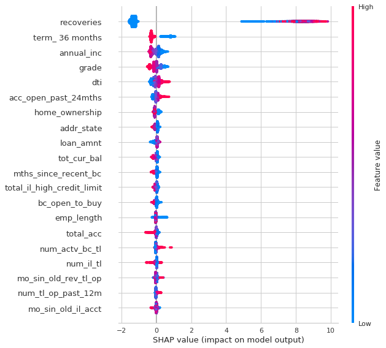

```
Experiment Succesfully Saved
```

```python
interpret_model(catboost)
save_experiment('catboost_expt_samp_2yrLCdata')
```